# Study Questions 2 --- BIOL 126

The largest group of equally related species to species c is: species e, species f, species g.

To solve this, follow the branch of species c back toward the root. At each internal node (vertical line), count how many species descend from the other side. Each such group is *equally related* to species c at that distance. You want the **largest** of these groups.

In the diagram below, species c is shown in orange, and the largest equally related group (species e, species f, species g) is shown in blue.

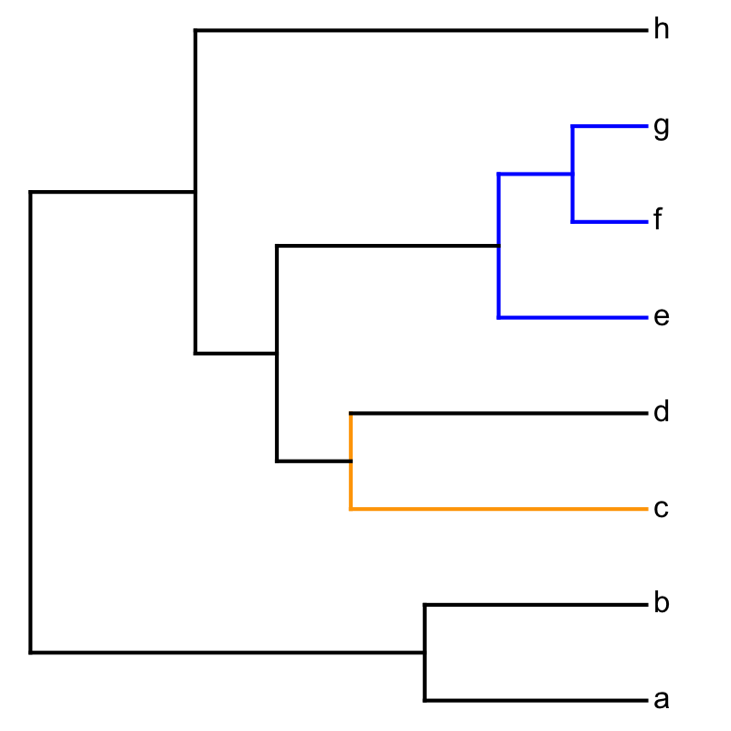

**Which species form the *largest group of equally related* species to species g?** Select all members of that group.

Note: there may be several *different* groups of equally related species to species g (at different distances), but you are looking for the **largest** of those groups.

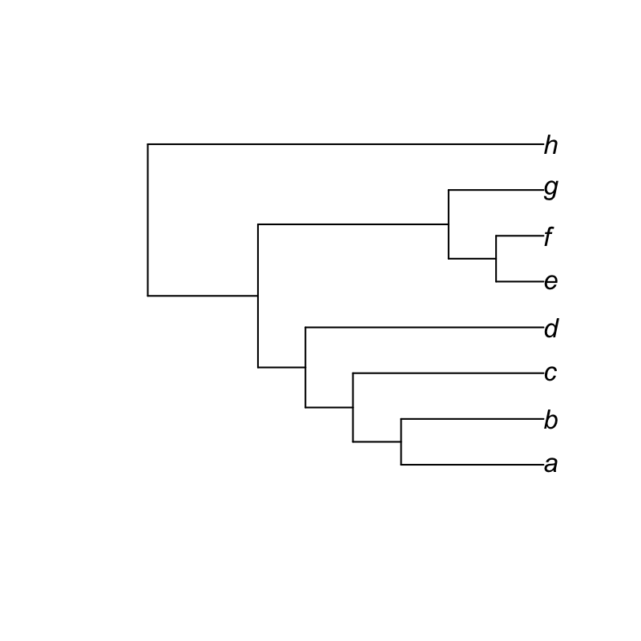

species aspecies bspecies cspecies dspecies especies fspecies h

The largest group of equally related species to species g is: species a, species b, species c, species d.

To solve this, follow the branch of species g back toward the root. At each internal node (vertical line), count how many species descend from the other side. Each such group is *equally related* to species g at that distance. You want the **largest** of these groups.

In the diagram below, species g is shown in orange, and the largest equally related group (species a, species b, species c, species d) is shown in blue.

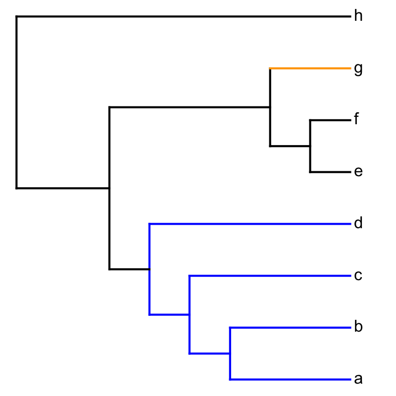

**Which species form the *largest group of equally related* species to species h?** Select all members of that group.

Note: there may be several *different* groups of equally related species to species h (at different distances), but you are looking for the **largest** of those groups.

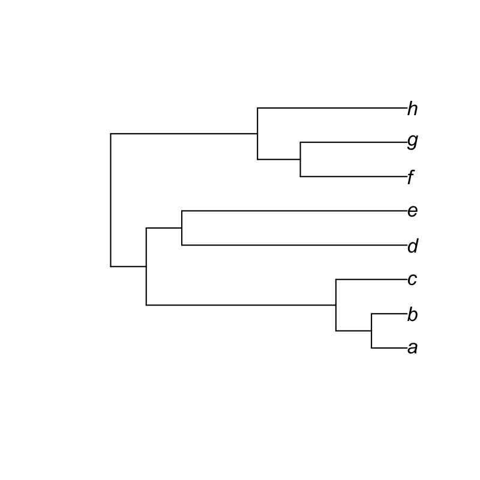

species aspecies bspecies cspecies dspecies especies fspecies g

The largest group of equally related species to species h is: species a, species b, species c, species d, species e.

To solve this, follow the branch of species h back toward the root. At each internal node (vertical line), count how many species descend from the other side. Each such group is *equally related* to species h at that distance. You want the **largest** of these groups.

In the diagram below, species h is shown in orange, and the largest equally related group (species a, species b, species c, species d, species e) is shown in blue.

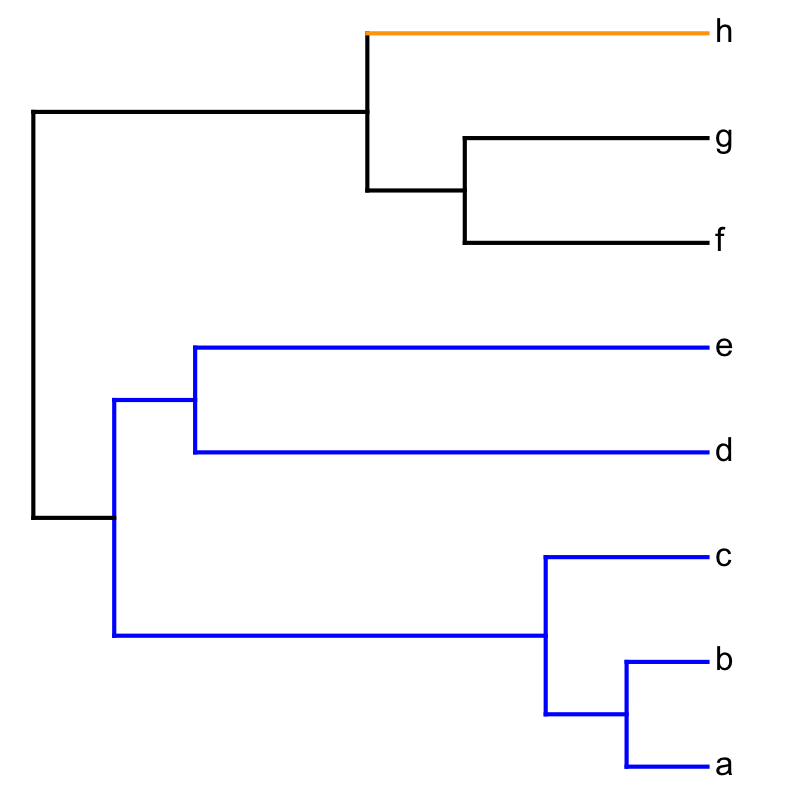

A conservation organization can fund reserves for exactly **three** of the species shown in the phylogenetic tree below. **Which set of three species would protect the greatest amount of evolutionary history (phylogenetic diversity)?**

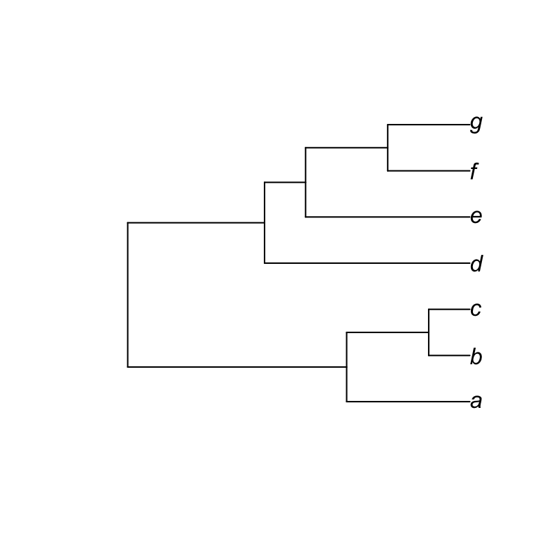

species b, c, especies b, c, gspecies a, c, gspecies a, c, fspecies b, d, e

The set with the highest phylogenetic diversity is species b, d, e.

To find this, start at the first (oldest) divergence event — the leftmost vertical line in the tree. To maximize evolutionary history, you need at least one species from each of the two main groups that split there. Then look at the older of those two lineages: follow it to the right and find where it diverges next. Again, pick one species from each daughter lineage. Occasionally a lineage has only one species — in that case it represents maximum diversity for that branch.

In the diagram below, the three major evolutionary lineages are highlighted in different colors. A set maximizing phylogenetic diversity contains one species from each color group. You can see that species b, d, e each belong to a different color group.

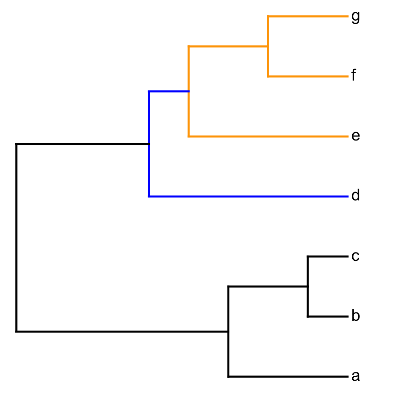

A conservation organization can fund reserves for exactly **three** of the species shown in the phylogenetic tree below. **Which set of three species would protect the greatest amount of evolutionary history (phylogenetic diversity)?**

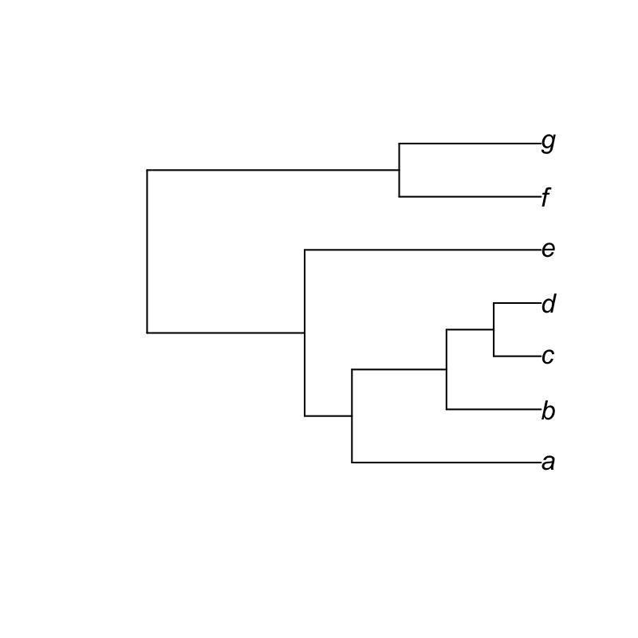

species d, e, fspecies a, c, fspecies b, c, dspecies b, c, gspecies a, c, d

The set with the highest phylogenetic diversity is species d, e, f.

To find this, start at the first (oldest) divergence event — the leftmost vertical line in the tree. To maximize evolutionary history, you need at least one species from each of the two main groups that split there. Then look at the older of those two lineages: follow it to the right and find where it diverges next. Again, pick one species from each daughter lineage. Occasionally a lineage has only one species — in that case it represents maximum diversity for that branch.

In the diagram below, the three major evolutionary lineages are highlighted in different colors. A set maximizing phylogenetic diversity contains one species from each color group. You can see that species d, e, f each belong to a different color group.

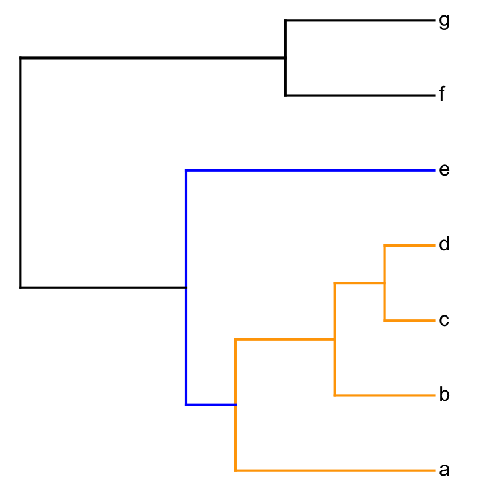

A conservation organization can fund reserves for exactly **three** of the species shown in the phylogenetic tree below. **Which set of three species would protect the greatest amount of evolutionary history (phylogenetic diversity)?**

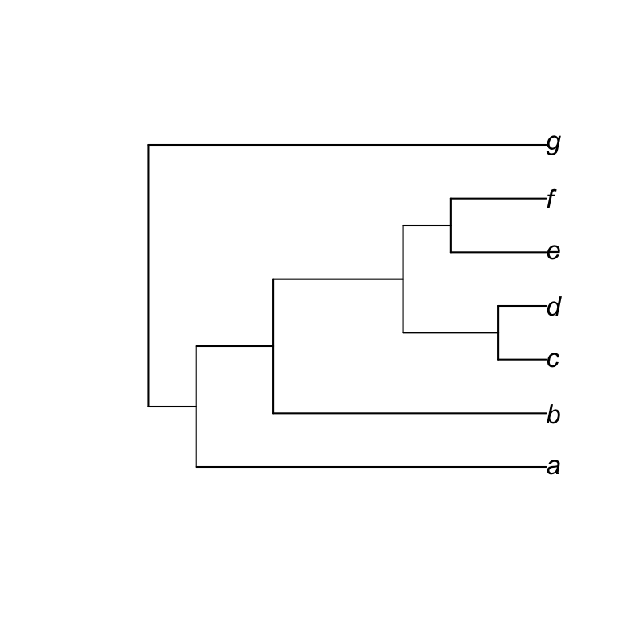

species c, d, gspecies e, f, gspecies b, c, dspecies a, e, fspecies a, f, g

The set with the highest phylogenetic diversity is species a, f, g.

To find this, start at the first (oldest) divergence event — the leftmost vertical line in the tree. To maximize evolutionary history, you need at least one species from each of the two main groups that split there. Then look at the older of those two lineages: follow it to the right and find where it diverges next. Again, pick one species from each daughter lineage. Occasionally a lineage has only one species — in that case it represents maximum diversity for that branch.

In the diagram below, the three major evolutionary lineages are highlighted in different colors. A set maximizing phylogenetic diversity contains one species from each color group. You can see that species a, f, g each belong to a different color group.

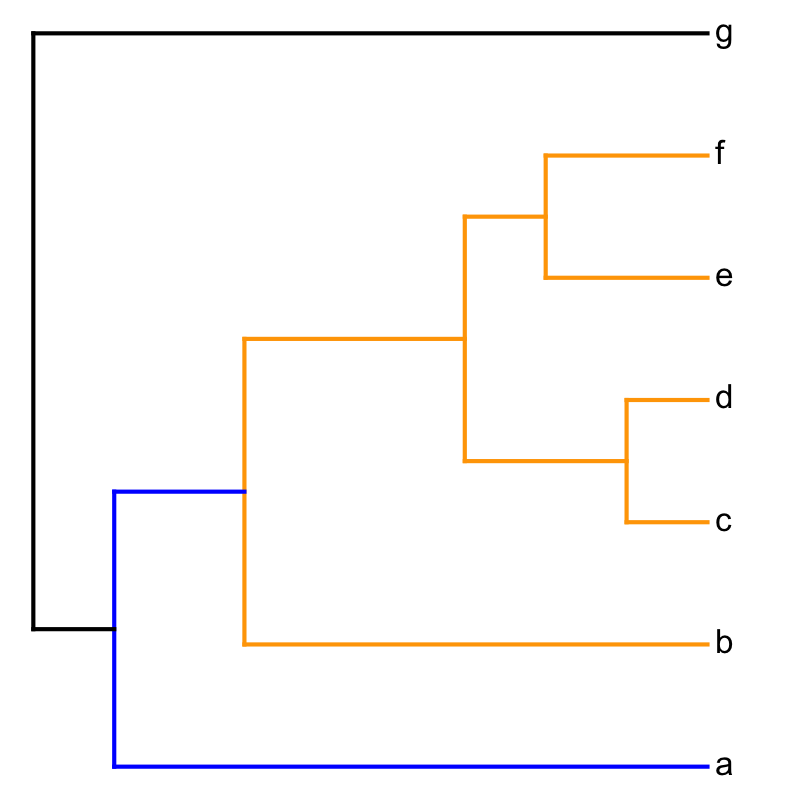

A conservation organization can fund reserves for exactly **three** of the species shown in the phylogenetic tree below. **Which set of three species would protect the greatest amount of evolutionary history (phylogenetic diversity)?**

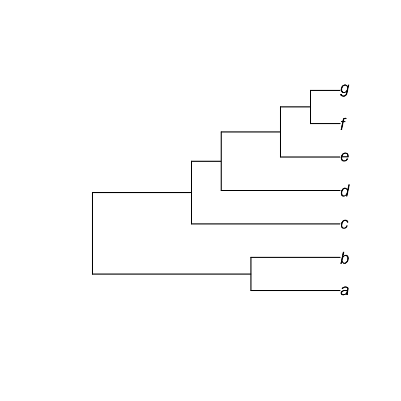

species b, d, fspecies b, c, especies b, f, gspecies b, d, gspecies a, e, g

The set with the highest phylogenetic diversity is species b, c, e.

To find this, start at the first (oldest) divergence event — the leftmost vertical line in the tree. To maximize evolutionary history, you need at least one species from each of the two main groups that split there. Then look at the older of those two lineages: follow it to the right and find where it diverges next. Again, pick one species from each daughter lineage. Occasionally a lineage has only one species — in that case it represents maximum diversity for that branch.

In the diagram below, the three major evolutionary lineages are highlighted in different colors. A set maximizing phylogenetic diversity contains one species from each color group. You can see that species b, c, e each belong to a different color group.

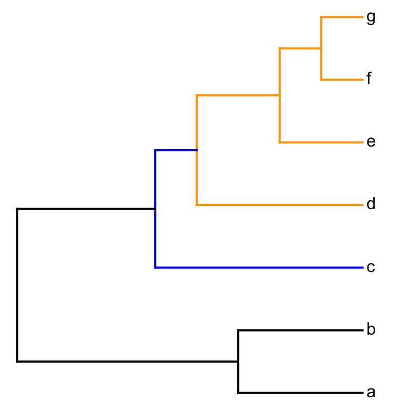

A conservation organization can fund reserves for exactly **three** of the species shown in the phylogenetic tree below. **Which set of three species would protect the greatest amount of evolutionary history (phylogenetic diversity)?**

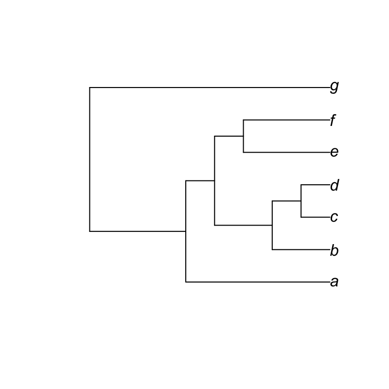

species b, c, gspecies c, d, especies b, d, gspecies a, d, gspecies a, b, c

The set with the highest phylogenetic diversity is species a, d, g.

To find this, start at the first (oldest) divergence event — the leftmost vertical line in the tree. To maximize evolutionary history, you need at least one species from each of the two main groups that split there. Then look at the older of those two lineages: follow it to the right and find where it diverges next. Again, pick one species from each daughter lineage. Occasionally a lineage has only one species — in that case it represents maximum diversity for that branch.

In the diagram below, the three major evolutionary lineages are highlighted in different colors. A set maximizing phylogenetic diversity contains one species from each color group. You can see that species a, d, g each belong to a different color group.

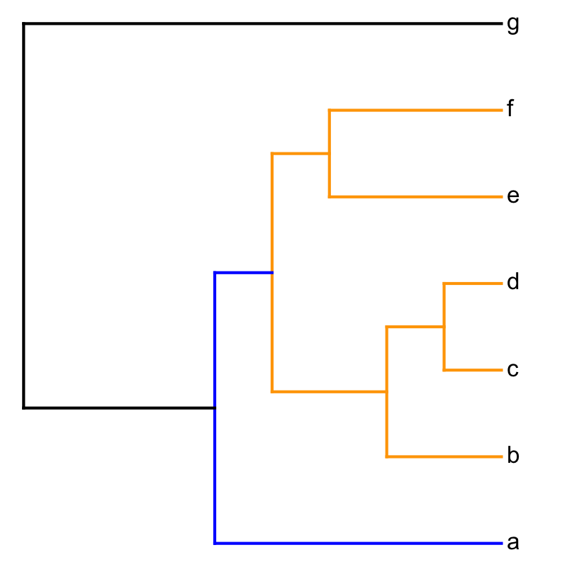

A conservation organization can fund reserves for exactly **three** of the species shown in the phylogenetic tree below. **Which set of three species would protect the greatest amount of evolutionary history (phylogenetic diversity)?**

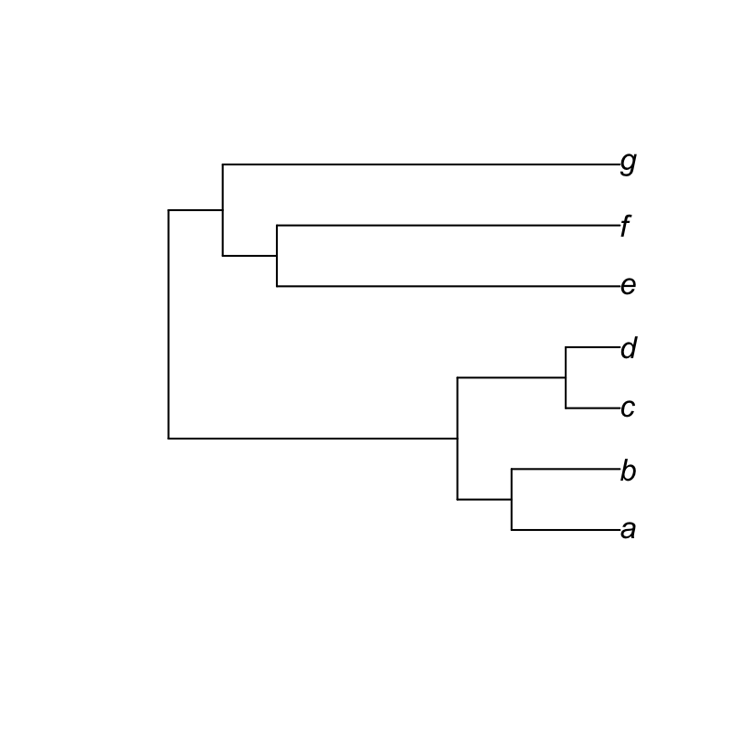

species a, e, gspecies b, d, fspecies a, b, gspecies a, d, especies a, b, d

The set with the highest phylogenetic diversity is species a, e, g.

To find this, start at the first (oldest) divergence event — the leftmost vertical line in the tree. To maximize evolutionary history, you need at least one species from each of the two main groups that split there. Then look at the older of those two lineages: follow it to the right and find where it diverges next. Again, pick one species from each daughter lineage. Occasionally a lineage has only one species — in that case it represents maximum diversity for that branch.

In the diagram below, the three major evolutionary lineages are highlighted in different colors. A set maximizing phylogenetic diversity contains one species from each color group. You can see that species a, e, g each belong to a different color group.

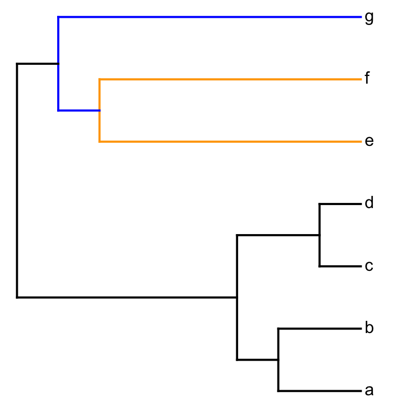

**Which set(s) of 3 species from the cladogram below would protect the greatest amount of evolutionary history?** Select all that apply — there may be one correct answer or several sets that are equally good.

*(At least one of the options shown has lower phylogenetic diversity than the best possible set.)*

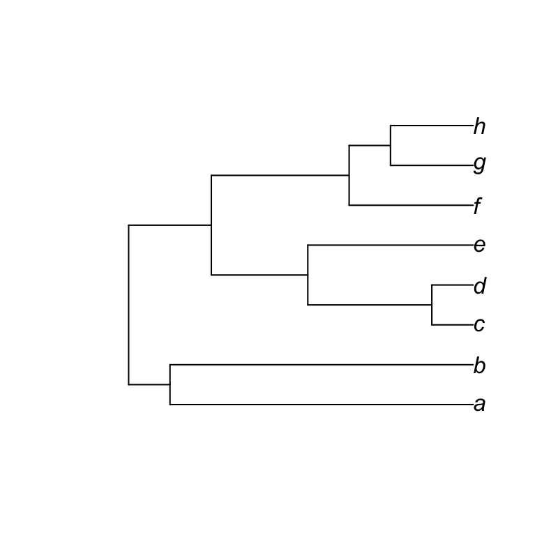

species a, b, hspecies a, b, fspecies a, b, cspecies a, b, especies b, d, f

The set(s) with the highest phylogenetic diversity is/are: species a, b, e; species a, b, c; species a, b, h; species a, b, f.

To find this, start at the root (leftmost vertical line). To capture maximum evolutionary history, include at least one species from each major branch. Then, within the older of those branches, find the first sub-divergence event and again pick one species from each daughter lineage. Occasionally a lineage has only one species — that's fine.

In the diagram below, the three major evolutionary lineages are shown in different colors. Any set with one species from each color group achieves the maximum phylogenetic diversity: species a, b, e; species a, b, c; species a, b, h; species a, b, f.

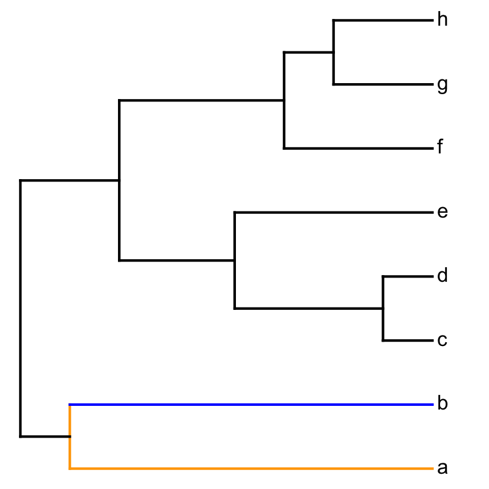

**Which set(s) of 3 species from the cladogram below would protect the greatest amount of evolutionary history?** Select all that apply — there may be one correct answer or several sets that are equally good.

*(At least one of the options shown has lower phylogenetic diversity than the best possible set.)*

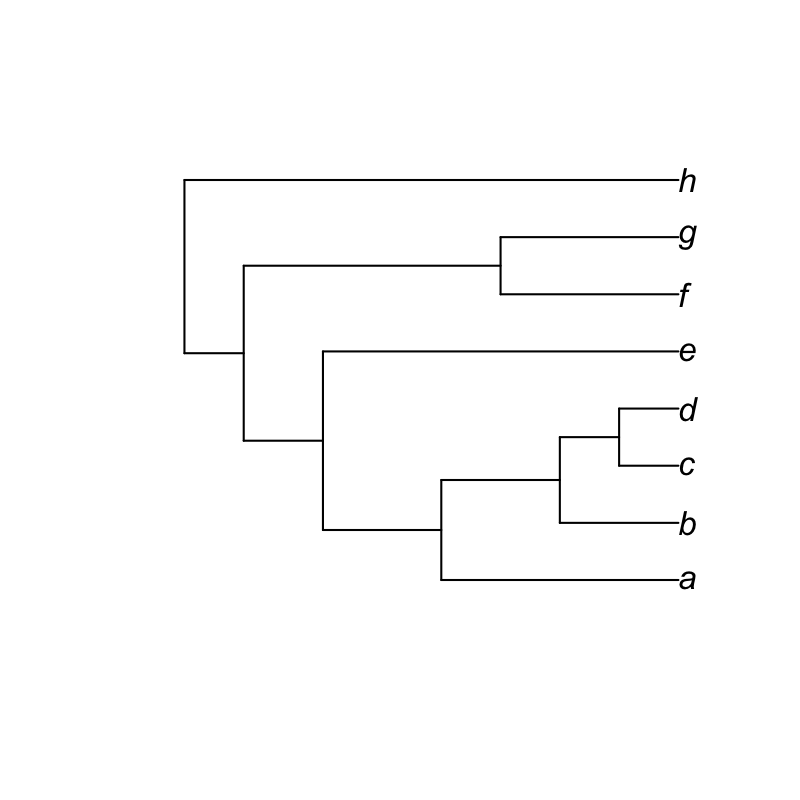

species a, f, gspecies a, c, dspecies b, d, hspecies a, c, fspecies d, f, h

The set(s) with the highest phylogenetic diversity is/are: species d, f, h.

To find this, start at the root (leftmost vertical line). To capture maximum evolutionary history, include at least one species from each major branch. Then, within the older of those branches, find the first sub-divergence event and again pick one species from each daughter lineage. Occasionally a lineage has only one species — that's fine.

In the diagram below, the three major evolutionary lineages are shown in different colors. Any set with one species from each color group achieves the maximum phylogenetic diversity: species d, f, h.

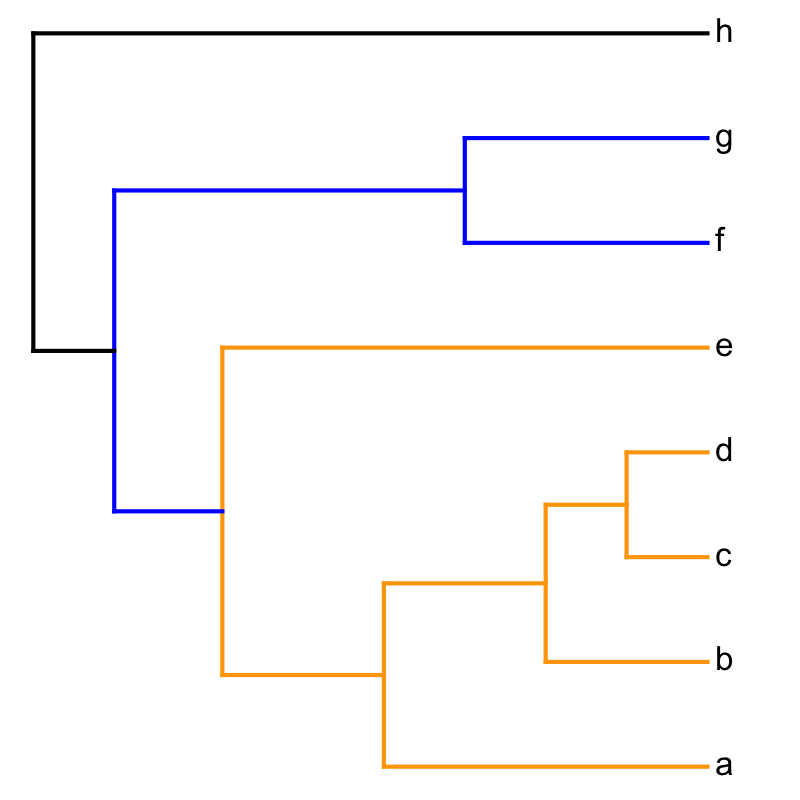

**Which set(s) of 3 species from the cladogram below would protect the greatest amount of evolutionary history?** Select all that apply — there may be one correct answer or several sets that are equally good.

*(At least one of the options shown has lower phylogenetic diversity than the best possible set.)*

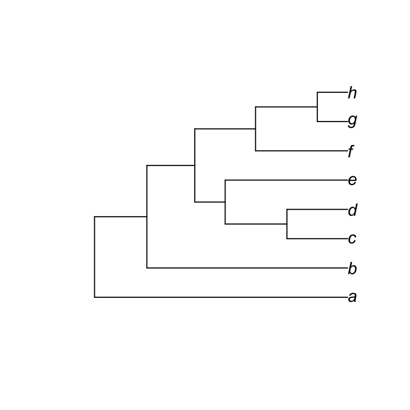

species a, d, hspecies b, c, dspecies e, g, hspecies a, f, gspecies a, b, d

The set(s) with the highest phylogenetic diversity is/are: species a, b, d.

To find this, start at the root (leftmost vertical line). To capture maximum evolutionary history, include at least one species from each major branch. Then, within the older of those branches, find the first sub-divergence event and again pick one species from each daughter lineage. Occasionally a lineage has only one species — that's fine.

In the diagram below, the three major evolutionary lineages are shown in different colors. Any set with one species from each color group achieves the maximum phylogenetic diversity: species a, b, d.

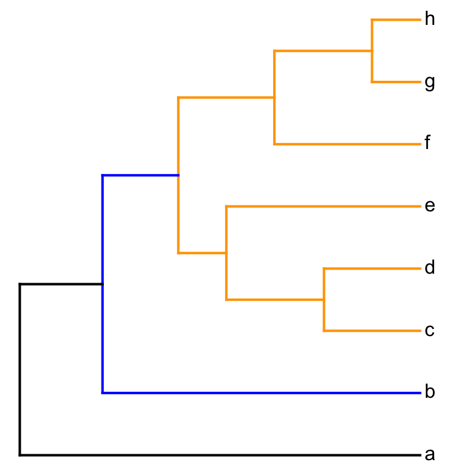

**Which set(s) of 3 species from the cladogram below would protect the greatest amount of evolutionary history?** Select all that apply — there may be one correct answer or several sets that are equally good.

*(At least one of the options shown has lower phylogenetic diversity than the best possible set.)*

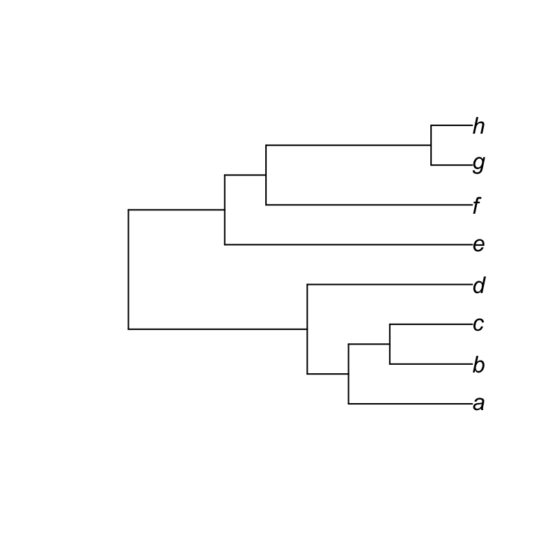

species c, e, hspecies a, e, hspecies d, e, gspecies b, c, fspecies d, e, h

The set(s) with the highest phylogenetic diversity is/are: species c, e, h; species a, e, h; species d, e, h; species d, e, g.

To find this, start at the root (leftmost vertical line). To capture maximum evolutionary history, include at least one species from each major branch. Then, within the older of those branches, find the first sub-divergence event and again pick one species from each daughter lineage. Occasionally a lineage has only one species — that's fine.

In the diagram below, the three major evolutionary lineages are shown in different colors. Any set with one species from each color group achieves the maximum phylogenetic diversity: species c, e, h; species a, e, h; species d, e, h; species d, e, g.

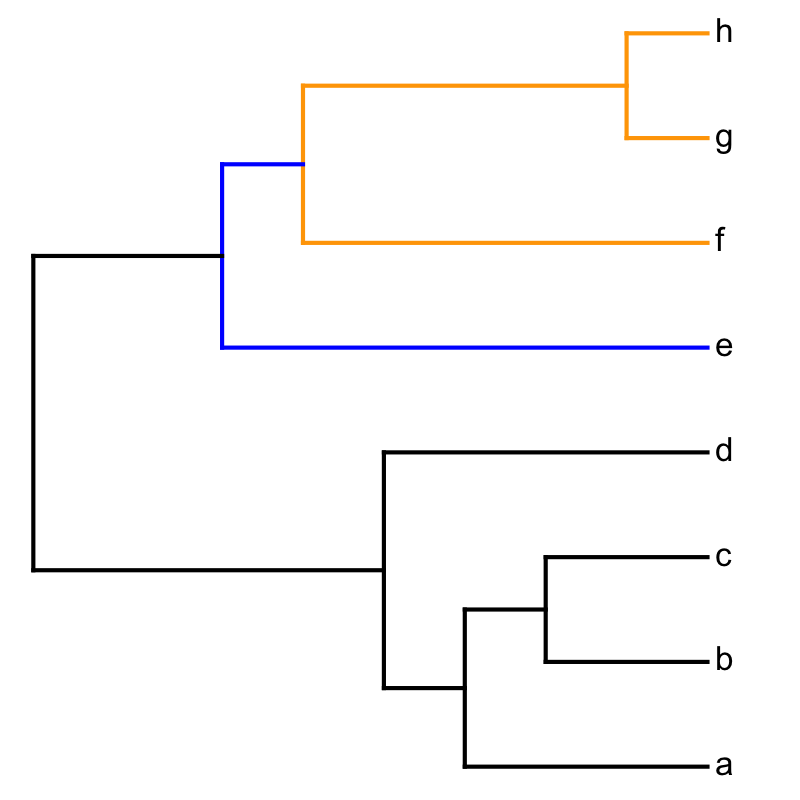

**Which set(s) of 3 species from the cladogram below would protect the greatest amount of evolutionary history?** Select all that apply — there may be one correct answer or several sets that are equally good.

*(At least one of the options shown has lower phylogenetic diversity than the best possible set.)*

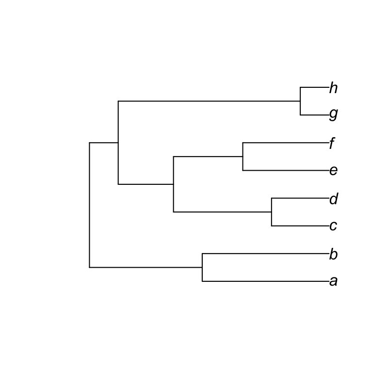

species a, c, especies c, g, hspecies a, d, hspecies e, f, hspecies d, f, h

The set(s) with the highest phylogenetic diversity is/are: species a, d, h.

To find this, start at the root (leftmost vertical line). To capture maximum evolutionary history, include at least one species from each major branch. Then, within the older of those branches, find the first sub-divergence event and again pick one species from each daughter lineage. Occasionally a lineage has only one species — that's fine.

In the diagram below, the three major evolutionary lineages are shown in different colors. Any set with one species from each color group achieves the maximum phylogenetic diversity: species a, d, h.

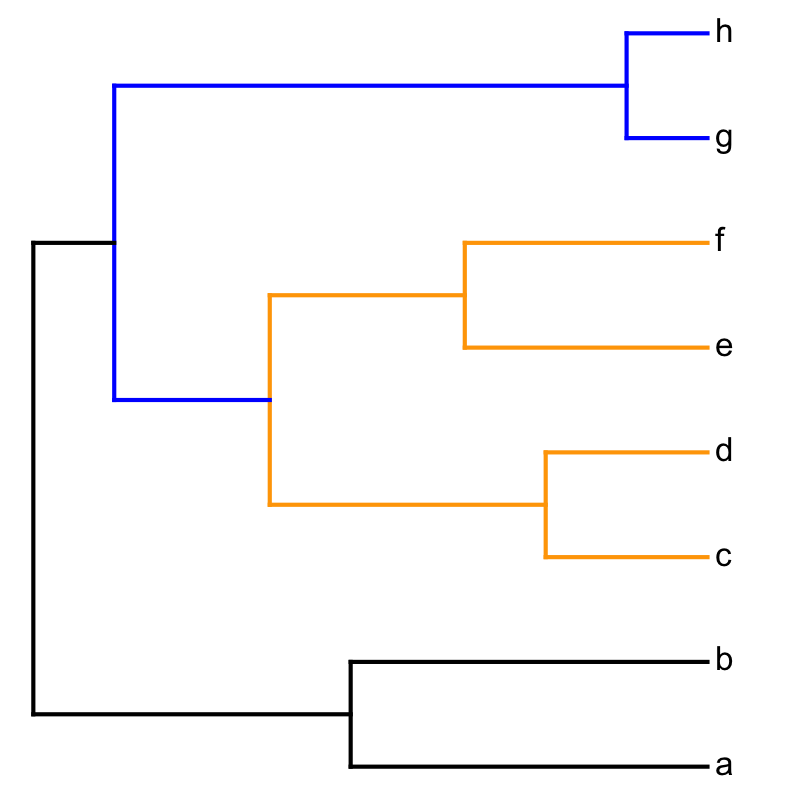

**Which set(s) of 3 species from the cladogram below would protect the greatest amount of evolutionary history?** Select all that apply — there may be one correct answer or several sets that are equally good.

*(At least one of the options shown has lower phylogenetic diversity than the best possible set.)*

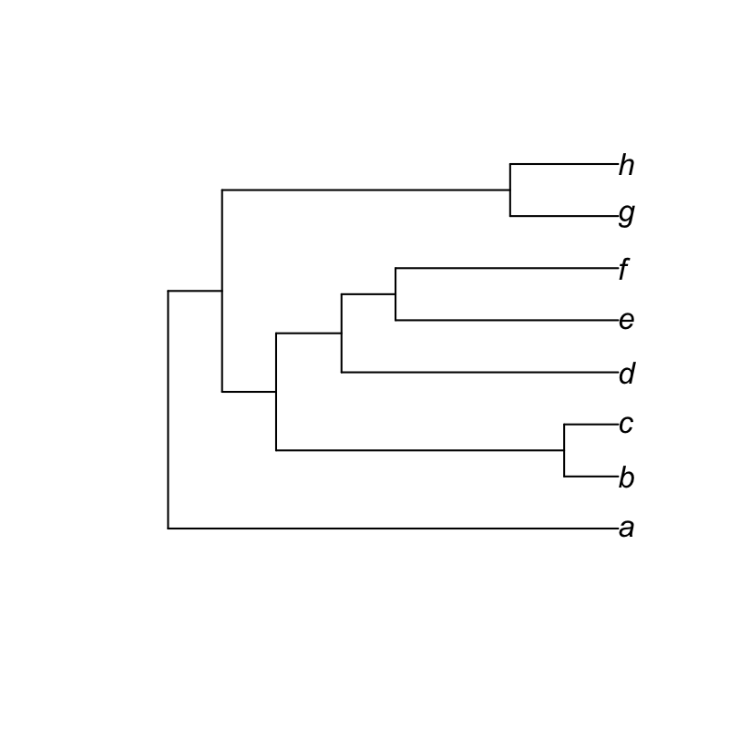

species a, b, gspecies b, g, hspecies e, g, hspecies b, f, hspecies a, c, d

The set(s) with the highest phylogenetic diversity is/are: species a, b, g.

To find this, start at the root (leftmost vertical line). To capture maximum evolutionary history, include at least one species from each major branch. Then, within the older of those branches, find the first sub-divergence event and again pick one species from each daughter lineage. Occasionally a lineage has only one species — that's fine.

In the diagram below, the three major evolutionary lineages are shown in different colors. Any set with one species from each color group achieves the maximum phylogenetic diversity: species a, b, g.

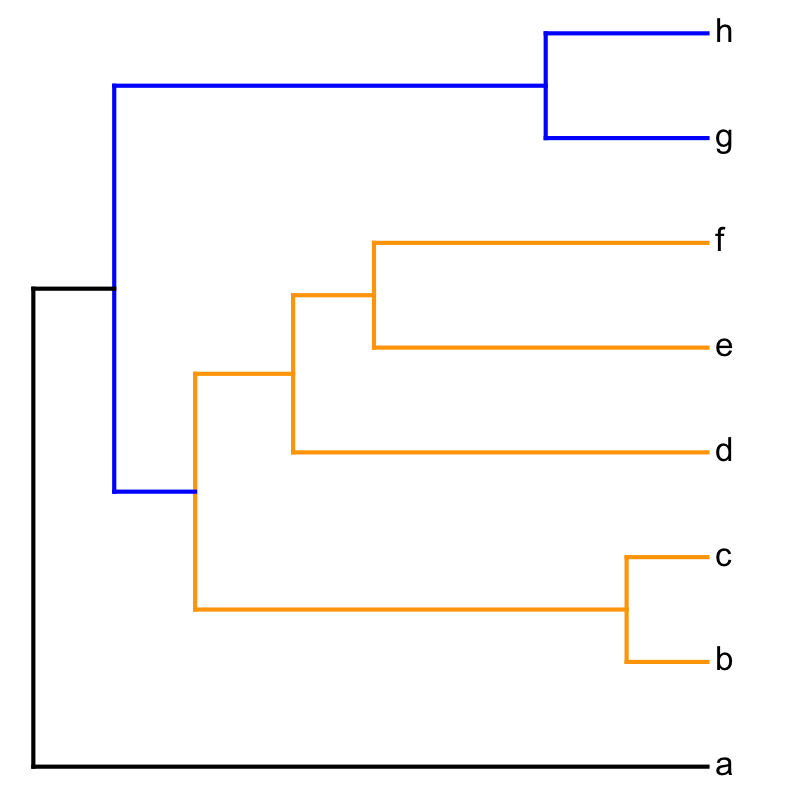

Tropical birds are among the most species-rich and most threatened groups of vertebrates on Earth. Suppose that background extinction rates for tropical forest birds are estimated to be approximately **5 extinction(s) per 10,000 species per year**. A survey of a large tropical forest region identifies approximately **5,000** bird species.

The calculation is straightforward:

$$\frac{5 \text{ extinctions}}{10{,}000
\text{ species per year}} \times 5,000\text{ species}$$

The units of "species" cancel from numerator and denominator, leaving us with extinctions per year:

$$= \frac{5 \times 5,000}{10{,}000} =
\frac{25000}{10{,}000} = 2.5$$

*Note: in the homework and quiz, you will encounter the same type of calculation but with the rate expressed as extinctions per **million** species per year (E/MSY). The process is identical — just substitute 1,000,000 in the denominator instead of 10,000.*

Tropical birds are among the most species-rich and most threatened groups of vertebrates on Earth. Suppose that background extinction rates for tropical forest birds are estimated to be approximately **5 extinction(s) per 10,000 species per year**. A survey of a large tropical forest region identifies approximately **7,000** bird species.

**How many bird species would be expected to go extinct in that region in a single year under background extinction rates?** Round to the nearest whole number.

We would expect **4 extinction(s) per year** given these parameters.

The calculation is straightforward:

$$\frac{5 \text{ extinctions}}{10{,}000
\text{ species per year}} \times 7,000\text{ species}$$

The units of "species" cancel from numerator and denominator, leaving us with extinctions per year:

$$= \frac{5 \times 7,000}{10{,}000} =
\frac{35000}{10{,}000} = 3.5$$

Rounded to the nearest whole number: **4 extinction(s)**.

*Note: in the homework and quiz, you will encounter the same type of calculation but with the rate expressed as extinctions per **million** species per year (E/MSY). The process is identical — just substitute 1,000,000 in the denominator instead of 10,000.*

Tropical birds are among the most species-rich and most threatened groups of vertebrates on Earth. Suppose that background extinction rates for tropical forest birds are estimated to be approximately **5 extinction(s) per 10,000 species per year**. A survey of a large tropical forest region identifies approximately **12,000** bird species.

**How many bird species would be expected to go extinct in that region in a single year under background extinction rates?** Round to the nearest whole number.

We would expect **6 extinction(s) per year** given these parameters.

The calculation is straightforward:

$$\frac{5 \text{ extinctions}}{10{,}000
\text{ species per year}} \times 12,000\text{ species}$$

The units of "species" cancel from numerator and denominator, leaving us with extinctions per year:

$$= \frac{5 \times 12,000}{10{,}000} =
\frac{60000}{10{,}000} = 6$$

Rounded to the nearest whole number: **6 extinction(s)**.

*Note: in the homework and quiz, you will encounter the same type of calculation but with the rate expressed as extinctions per **million** species per year (E/MSY). The process is identical — just substitute 1,000,000 in the denominator instead of 10,000.*

Tropical birds are among the most species-rich and most threatened groups of vertebrates on Earth. Suppose that background extinction rates for tropical forest birds are estimated to be approximately **3 extinction(s) per 10,000 species per year**. A survey of a large tropical forest region identifies approximately **12,000** bird species.

**How many bird species would be expected to go extinct in that region in a single year under background extinction rates?** Round to the nearest whole number.

We would expect **4 extinction(s) per year** given these parameters.

The calculation is straightforward:

$$\frac{3 \text{ extinctions}}{10{,}000
\text{ species per year}} \times 12,000\text{ species}$$

The units of "species" cancel from numerator and denominator, leaving us with extinctions per year:

$$= \frac{3 \times 12,000}{10{,}000} =
\frac{36000}{10{,}000} = 3.6$$

Rounded to the nearest whole number: **4 extinction(s)**.

*Note: in the homework and quiz, you will encounter the same type of calculation but with the rate expressed as extinctions per **million** species per year (E/MSY). The process is identical — just substitute 1,000,000 in the denominator instead of 10,000.*

Tropical birds are among the most species-rich and most threatened groups of vertebrates on Earth. Suppose that background extinction rates for tropical forest birds are estimated to be approximately **6 extinction(s) per 10,000 species per year**. A survey of a large tropical forest region identifies approximately **10,000** bird species.

**How many bird species would be expected to go extinct in that region in a single year under background extinction rates?** Round to the nearest whole number.

We would expect **6 extinction(s) per year** given these parameters.

The calculation is straightforward:

$$\frac{6 \text{ extinctions}}{10{,}000
\text{ species per year}} \times 10,000\text{ species}$$

The units of "species" cancel from numerator and denominator, leaving us with extinctions per year:

$$= \frac{6 \times 10,000}{10{,}000} =
\frac{60000}{10{,}000} = 6$$

Rounded to the nearest whole number: **6 extinction(s)**.

*Note: in the homework and quiz, you will encounter the same type of calculation but with the rate expressed as extinctions per **million** species per year (E/MSY). The process is identical — just substitute 1,000,000 in the denominator instead of 10,000.*

Tropical birds are among the most species-rich and most threatened groups of vertebrates on Earth. Suppose that background extinction rates for tropical forest birds are estimated to be approximately **4 extinction(s) per 10,000 species per year**. A survey of a large tropical forest region identifies approximately **9,000** bird species.

**How many bird species would be expected to go extinct in that region in a single year under background extinction rates?** Round to the nearest whole number.

We would expect **4 extinction(s) per year** given these parameters.

The calculation is straightforward:

$$\frac{4 \text{ extinctions}}{10{,}000
\text{ species per year}} \times 9,000\text{ species}$$

The units of "species" cancel from numerator and denominator, leaving us with extinctions per year:

$$= \frac{4 \times 9,000}{10{,}000} =
\frac{36000}{10{,}000} = 3.6$$

Rounded to the nearest whole number: **4 extinction(s)**.

*Note: in the homework and quiz, you will encounter the same type of calculation but with the rate expressed as extinctions per **million** species per year (E/MSY). The process is identical — just substitute 1,000,000 in the denominator instead of 10,000.*

Biologists studying extinction trends in tropical forest birds compiled records from museum collections, field surveys, and published reports. Over the last 50 years, **60 bird species** in the region are documented to have gone extinct. Based on fossil evidence and long-term background rates, scientists estimate that only **4 species** would have been expected to go extinct over that same 50-year period under background conditions.

**By what factor is the current (observed) extinction rate higher than the background (historical) rate?** Round your answer to one decimal place.

The current extinction rate is **15 times higher** than the background rate.

We calculate this as:

$$\frac{\text{observed
extinctions}}{\text{expected extinctions}} = \frac{60}{4} =
15$$

Rounded to one decimal place: **15**.

*Note: in the homework and quiz, the observed and expected counts are derived from background rates given in E/MSY (extinctions per million species per year). The ratio calculation here is identical — the only difference is how the expected count is computed first.*

Biologists studying extinction trends in tropical forest birds compiled records from museum collections, field surveys, and published reports. Over the last 50 years, **35 bird species** in the region are documented to have gone extinct. Based on fossil evidence and long-term background rates, scientists estimate that only **3 species** would have been expected to go extinct over that same 50-year period under background conditions.

**By what factor is the current (observed) extinction rate higher than the background (historical) rate?** Round your answer to one decimal place.

The current extinction rate is **11.7 times higher** than the background rate.

We calculate this as:

$$\frac{\text{observed
extinctions}}{\text{expected extinctions}} = \frac{35}{3} =
11.6666667$$

Rounded to one decimal place: **11.7**.

*Note: in the homework and quiz, the observed and expected counts are derived from background rates given in E/MSY (extinctions per million species per year). The ratio calculation here is identical — the only difference is how the expected count is computed first.*

Biologists studying extinction trends in tropical forest birds compiled records from museum collections, field surveys, and published reports. Over the last 50 years, **45 bird species** in the region are documented to have gone extinct. Based on fossil evidence and long-term background rates, scientists estimate that only **3 species** would have been expected to go extinct over that same 50-year period under background conditions.

**By what factor is the current (observed) extinction rate higher than the background (historical) rate?** Round your answer to one decimal place.

The current extinction rate is **15 times higher** than the background rate.

We calculate this as:

$$\frac{\text{observed
extinctions}}{\text{expected extinctions}} = \frac{45}{3} =
15$$

Rounded to one decimal place: **15**.

*Note: in the homework and quiz, the observed and expected counts are derived from background rates given in E/MSY (extinctions per million species per year). The ratio calculation here is identical — the only difference is how the expected count is computed first.*

Biologists studying extinction trends in tropical forest birds compiled records from museum collections, field surveys, and published reports. Over the last 50 years, **30 bird species** in the region are documented to have gone extinct. Based on fossil evidence and long-term background rates, scientists estimate that only **4 species** would have been expected to go extinct over that same 50-year period under background conditions.

**By what factor is the current (observed) extinction rate higher than the background (historical) rate?** Round your answer to one decimal place.

The current extinction rate is **7.5 times higher** than the background rate.

We calculate this as:

$$\frac{\text{observed
extinctions}}{\text{expected extinctions}} = \frac{30}{4} =
7.5$$

Rounded to one decimal place: **7.5**.

*Note: in the homework and quiz, the observed and expected counts are derived from background rates given in E/MSY (extinctions per million species per year). The ratio calculation here is identical — the only difference is how the expected count is computed first.*

Biologists studying extinction trends in tropical forest birds compiled records from museum collections, field surveys, and published reports. Over the last 50 years, **15 bird species** in the region are documented to have gone extinct. Based on fossil evidence and long-term background rates, scientists estimate that only **4 species** would have been expected to go extinct over that same 50-year period under background conditions.

**By what factor is the current (observed) extinction rate higher than the background (historical) rate?** Round your answer to one decimal place.

The current extinction rate is **3.8 times higher** than the background rate.

We calculate this as:

$$\frac{\text{observed
extinctions}}{\text{expected extinctions}} = \frac{15}{4} =
3.75$$

Rounded to one decimal place: **3.8**.

*Note: in the homework and quiz, the observed and expected counts are derived from background rates given in E/MSY (extinctions per million species per year). The ratio calculation here is identical — the only difference is how the expected count is computed first.*

Biologists studying extinction trends in tropical forest birds compiled records from museum collections, field surveys, and published reports. Over the last 50 years, **20 bird species** in the region are documented to have gone extinct. Based on fossil evidence and long-term background rates, scientists estimate that only **3 species** would have been expected to go extinct over that same 50-year period under background conditions.

**By what factor is the current (observed) extinction rate higher than the background (historical) rate?** Round your answer to one decimal place.

The current extinction rate is **6.7 times higher** than the background rate.

We calculate this as:

$$\frac{\text{observed
extinctions}}{\text{expected extinctions}} = \frac{20}{3} =
6.6666667$$

Rounded to one decimal place: **6.7**.

*Note: in the homework and quiz, the observed and expected counts are derived from background rates given in E/MSY (extinctions per million species per year). The ratio calculation here is identical — the only difference is how the expected count is computed first.*

Estimates from tropical bird surveys suggest that current bird extinction rates are approximately **20 times higher** than the background extinction rate. Assume the background extinction rate is 1 species extinction per 10,000 species per year. There are approximately **8,000** tropical bird species.

**How many tropical bird species would be expected to go extinct in a single year at the current (elevated) rate?** Round to the nearest whole number.

We would expect approximately **16 extinction(s) per year** under current rates.

Since the background rate is 1 per 10,000 species per year, and current rates are 20 times higher, the current rate is:

$$\frac{20 \text{ extinctions}}{10{,}000
\text{ species per year}}$$

Multiplying by the total number of species (and by 1 year) gives:

$$\frac{20}{10{,}000} \times 8,000\text{
species} = \frac{160000}{10{,}000} = 16$$

Rounded: **16 extinction(s)**.

*Note: in the homework and quiz, the background rate is given in E/MSY (extinctions per million species per year) and species counts are in the millions. The logic is the same — substitute 1,000,000 for 10,000 and millions of species for thousands.*

Estimates from tropical bird surveys suggest that current bird extinction rates are approximately **50 times higher** than the background extinction rate. Assume the background extinction rate is 1 species extinction per 10,000 species per year. There are approximately **5,000** tropical bird species.

**How many tropical bird species would be expected to go extinct in a single year at the current (elevated) rate?** Round to the nearest whole number.

We would expect approximately **25 extinction(s) per year** under current rates.

Since the background rate is 1 per 10,000 species per year, and current rates are 50 times higher, the current rate is:

$$\frac{50 \text{ extinctions}}{10{,}000
\text{ species per year}}$$

Multiplying by the total number of species (and by 1 year) gives:

$$\frac{50}{10{,}000} \times 5,000\text{
species} = \frac{250000}{10{,}000} = 25$$

Rounded: **25 extinction(s)**.

*Note: in the homework and quiz, the background rate is given in E/MSY (extinctions per million species per year) and species counts are in the millions. The logic is the same — substitute 1,000,000 for 10,000 and millions of species for thousands.*

Estimates from tropical bird surveys suggest that current bird extinction rates are approximately **75 times higher** than the background extinction rate. Assume the background extinction rate is 1 species extinction per 10,000 species per year. There are approximately **5,000** tropical bird species.

**How many tropical bird species would be expected to go extinct in a single year at the current (elevated) rate?** Round to the nearest whole number.

We would expect approximately **38 extinction(s) per year** under current rates.

Since the background rate is 1 per 10,000 species per year, and current rates are 75 times higher, the current rate is:

$$\frac{75 \text{ extinctions}}{10{,}000
\text{ species per year}}$$

Multiplying by the total number of species (and by 1 year) gives:

$$\frac{75}{10{,}000} \times 5,000\text{
species} = \frac{375000}{10{,}000} = 37.5$$

Rounded: **38 extinction(s)**.

*Note: in the homework and quiz, the background rate is given in E/MSY (extinctions per million species per year) and species counts are in the millions. The logic is the same — substitute 1,000,000 for 10,000 and millions of species for thousands.*

Estimates from tropical bird surveys suggest that current bird extinction rates are approximately **10 times higher** than the background extinction rate. Assume the background extinction rate is 1 species extinction per 10,000 species per year. There are approximately **3,000** tropical bird species.

**How many tropical bird species would be expected to go extinct in a single year at the current (elevated) rate?** Round to the nearest whole number.

We would expect approximately **3 extinction(s) per year** under current rates.

Since the background rate is 1 per 10,000 species per year, and current rates are 10 times higher, the current rate is:

$$\frac{10 \text{ extinctions}}{10{,}000
\text{ species per year}}$$

Multiplying by the total number of species (and by 1 year) gives:

$$\frac{10}{10{,}000} \times 3,000\text{
species} = \frac{30000}{10{,}000} = 3$$

Rounded: **3 extinction(s)**.

*Note: in the homework and quiz, the background rate is given in E/MSY (extinctions per million species per year) and species counts are in the millions. The logic is the same — substitute 1,000,000 for 10,000 and millions of species for thousands.*

Estimates from tropical bird surveys suggest that current bird extinction rates are approximately **50 times higher** than the background extinction rate. Assume the background extinction rate is 1 species extinction per 10,000 species per year. There are approximately **4,000** tropical bird species.

**How many tropical bird species would be expected to go extinct in a single year at the current (elevated) rate?** Round to the nearest whole number.

We would expect approximately **20 extinction(s) per year** under current rates.

Since the background rate is 1 per 10,000 species per year, and current rates are 50 times higher, the current rate is:

$$\frac{50 \text{ extinctions}}{10{,}000
\text{ species per year}}$$

Multiplying by the total number of species (and by 1 year) gives:

$$\frac{50}{10{,}000} \times 4,000\text{
species} = \frac{200000}{10{,}000} = 20$$

Rounded: **20 extinction(s)**.

*Note: in the homework and quiz, the background rate is given in E/MSY (extinctions per million species per year) and species counts are in the millions. The logic is the same — substitute 1,000,000 for 10,000 and millions of species for thousands.*

Estimates from tropical bird surveys suggest that current bird extinction rates are approximately **10 times higher** than the background extinction rate. Assume the background extinction rate is 1 species extinction per 10,000 species per year. There are approximately **4,000** tropical bird species.

**How many tropical bird species would be expected to go extinct in a single year at the current (elevated) rate?** Round to the nearest whole number.

We would expect approximately **4 extinction(s) per year** under current rates.

Since the background rate is 1 per 10,000 species per year, and current rates are 10 times higher, the current rate is:

$$\frac{10 \text{ extinctions}}{10{,}000
\text{ species per year}}$$

Multiplying by the total number of species (and by 1 year) gives:

$$\frac{10}{10{,}000} \times 4,000\text{
species} = \frac{40000}{10{,}000} = 4$$

Rounded: **4 extinction(s)**.

*Note: in the homework and quiz, the background rate is given in E/MSY (extinctions per million species per year) and species counts are in the millions. The logic is the same — substitute 1,000,000 for 10,000 and millions of species for thousands.*

Ecologists set up experimental grassland plots with varying levels of plant species richness and measured net primary productivity (the amount of biomass produced per year) in each plot. The data from this fictional experiment are shown below.

**Does this dataset show a biodiversity–ecosystem function (BEF) relationship?**

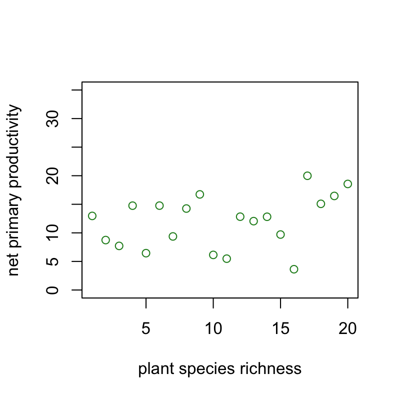

there is no discernible relationship between biodiversity and ecosystem functioningthere is a discernible **positive** relationship between biodiversity and ecosystem functioningthere is a discernible **negative** relationship between biodiversity and ecosystem functioningcannot tell with the information given

There is **no** relationship between plant species richness and grassland productivity in this dataset; the slope of the line is not distinguishable from zero. Primary productivity is roughly the same regardless of how many plant species are present. The dotted line in the graph below shows the fitted relationship: flat (slope ≈ 0) when there is no BEF, or upward when there is a positive BEF.

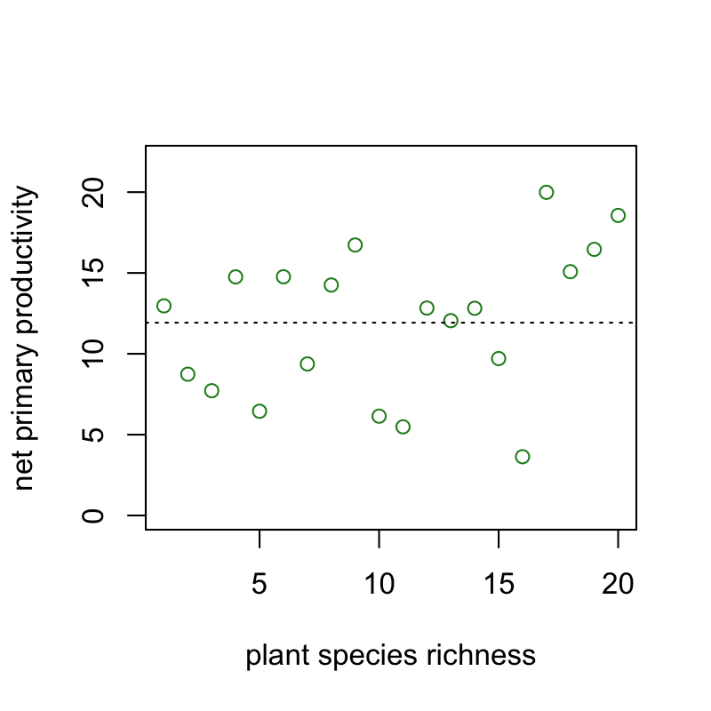

Ecologists set up experimental grassland plots with varying levels of plant species richness and measured net primary productivity (the amount of biomass produced per year) in each plot. The data from this fictional experiment are shown below.

**Does this dataset show a biodiversity–ecosystem function (BEF) relationship?**

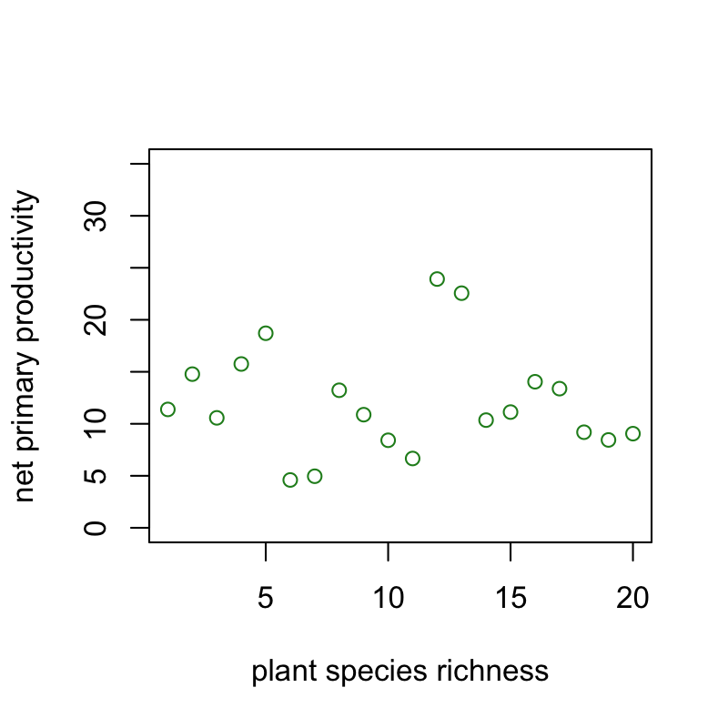

there is no discernible relationship between biodiversity and ecosystem functioningthere is a discernible **positive** relationship between biodiversity and ecosystem functioningthere is a discernible **negative** relationship between biodiversity and ecosystem functioningcannot tell with the information given

There is **no** relationship between plant species richness and grassland productivity in this dataset; the slope of the line is not distinguishable from zero. Primary productivity is roughly the same regardless of how many plant species are present. The dotted line in the graph below shows the fitted relationship: flat (slope ≈ 0) when there is no BEF, or upward when there is a positive BEF.

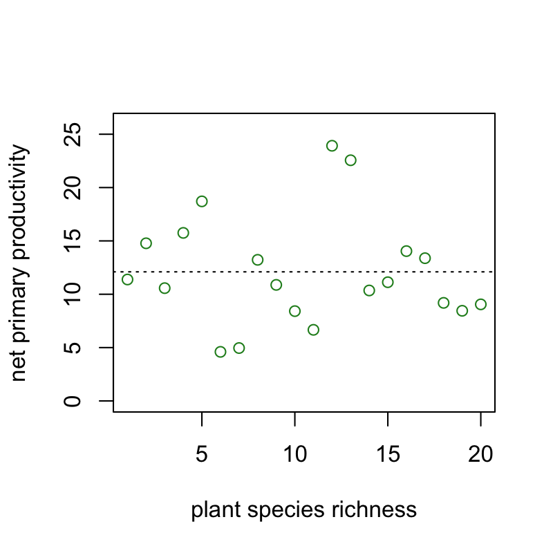

Ecologists set up experimental grassland plots with varying levels of plant species richness and measured net primary productivity (the amount of biomass produced per year) in each plot. The data from this fictional experiment are shown below.

**Does this dataset show a biodiversity–ecosystem function (BEF) relationship?**

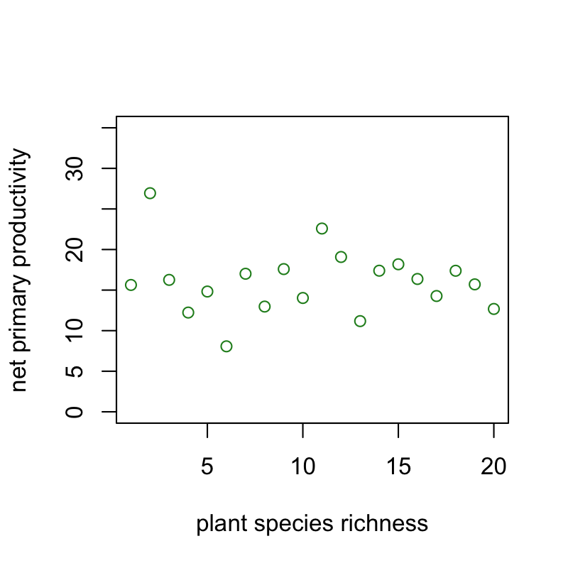

there is no discernible relationship between biodiversity and ecosystem functioningthere is a discernible **positive** relationship between biodiversity and ecosystem functioningthere is a discernible **negative** relationship between biodiversity and ecosystem functioningcannot tell with the information given

There is **no** relationship between plant species richness and grassland productivity in this dataset; the slope of the line is not distinguishable from zero. Primary productivity is roughly the same regardless of how many plant species are present. The dotted line in the graph below shows the fitted relationship: flat (slope ≈ 0) when there is no BEF, or upward when there is a positive BEF.

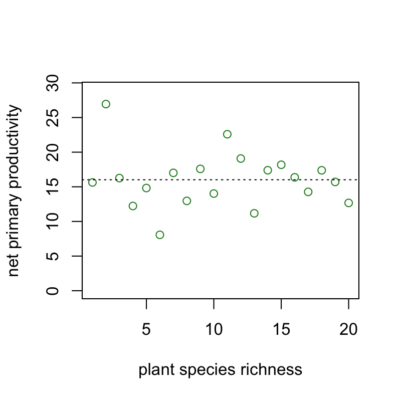

Ecologists set up experimental grassland plots with varying levels of plant species richness and measured net primary productivity (the amount of biomass produced per year) in each plot. The data from this fictional experiment are shown below.

**Does this dataset show a biodiversity–ecosystem function (BEF) relationship?**

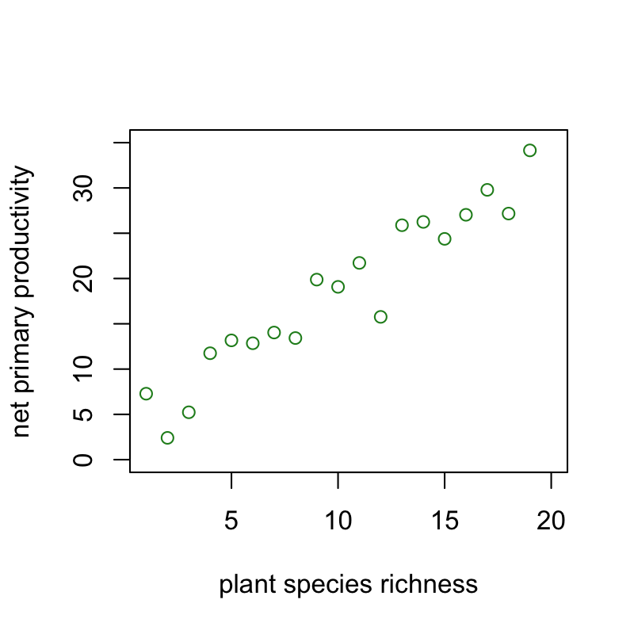

there is no discernible relationship between biodiversity and ecosystem functioningthere is a discernible **positive** relationship between biodiversity and ecosystem functioningthere is a discernible **negative** relationship between biodiversity and ecosystem functioningcannot tell with the information given

There **IS** a positive relationship between plant species richness and grassland productivity in this dataset; the slope is clearly positive and distinguishable from zero. The dotted line in the graph below shows the fitted relationship: flat (slope ≈ 0) when there is no BEF, or upward when there is a positive BEF.

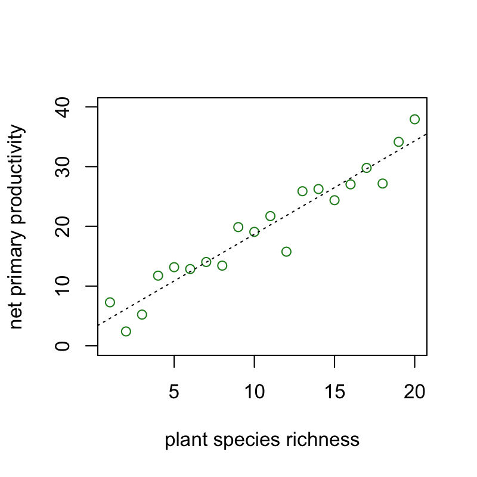

Ecologists set up experimental grassland plots with varying levels of plant species richness and measured net primary productivity (the amount of biomass produced per year) in each plot. The data from this fictional experiment are shown below.

**Does this dataset show a biodiversity–ecosystem function (BEF) relationship?**

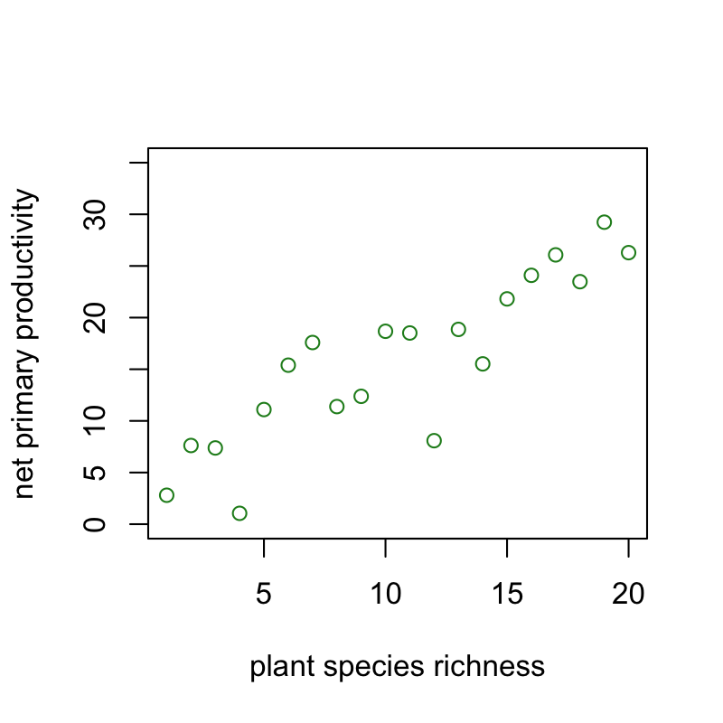

there is no discernible relationship between biodiversity and ecosystem functioningthere is a discernible **positive** relationship between biodiversity and ecosystem functioningthere is a discernible **negative** relationship between biodiversity and ecosystem functioningcannot tell with the information given

There **IS** a positive relationship between plant species richness and grassland productivity in this dataset; the slope is clearly positive and distinguishable from zero. The dotted line in the graph below shows the fitted relationship: flat (slope ≈ 0) when there is no BEF, or upward when there is a positive BEF.

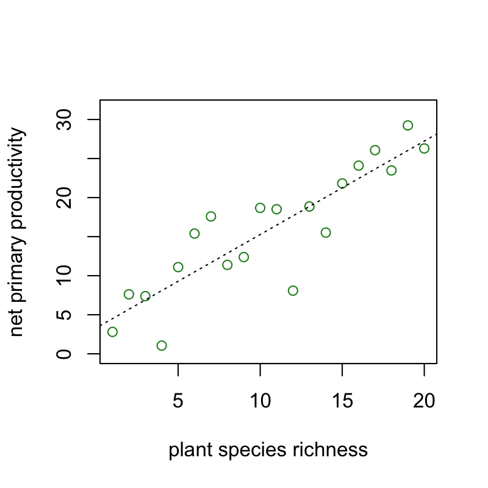

Ecologists set up experimental grassland plots with varying levels of plant species richness and measured net primary productivity (the amount of biomass produced per year) in each plot. The data from this fictional experiment are shown below.

**Does this dataset show a biodiversity–ecosystem function (BEF) relationship?**

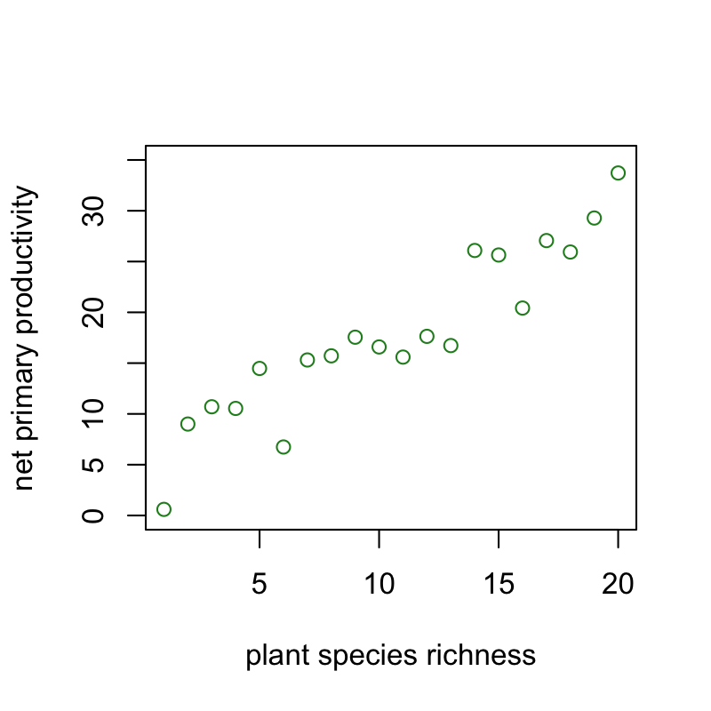

there is no discernible relationship between biodiversity and ecosystem functioningthere is a discernible **positive** relationship between biodiversity and ecosystem functioningthere is a discernible **negative** relationship between biodiversity and ecosystem functioningcannot tell with the information given

There **IS** a positive relationship between plant species richness and grassland productivity in this dataset; the slope is clearly positive and distinguishable from zero. The dotted line in the graph below shows the fitted relationship: flat (slope ≈ 0) when there is no BEF, or upward when there is a positive BEF.

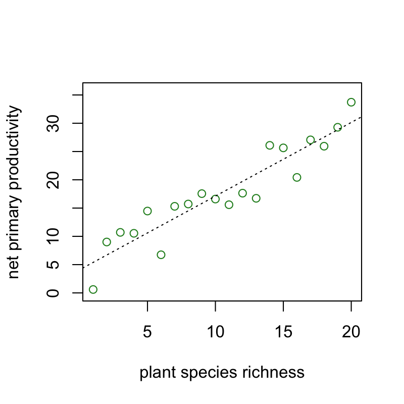

Which of the following are examples of **instrumental values** of biodiversity? (Select all that apply.)

Arguing that a rare cave beetle should be protected even though it has no known human use and no one has any relationship with itProtecting coral reef biodiversity because reefs support tourism and fisheries industries that entire island economies depend onEnjoying birdwatching in a national park---a form of ecotourism that generates income for local communities and justifies conservation fundingBelieving that allowing any species to go extinct is morally wrong, regardless of whether that species benefits peopleSupporting conservation of a river because your family has fished there for generations and it is central to your sense of identityArguing against development of a rainforest tract because the unknown diversity there might harbor compounds no scientist has yet studied

**Instrumental value** means that biodiversity is valuable because of the benefits it provides to humans — either directly (food, medicine, materials, recreation), indirectly (ecosystem services such as water purification, pollination, climate regulation, and coastal protection), or as potential future value (option value, a subtype of instrumental value).

The incorrect answers describe: - **Intrinsic value**: species have worth independent of any human benefit or awareness. - **Relational value**: value arises from personal or cultural relationships with nature. - **Moral/ethical/religious value**: conservation is motivated by duty, obligation, or spiritual teaching rather than benefit.

Which of the following are examples of **instrumental values** of biodiversity? (Select all that apply.)

Using the naturally derived insecticide azadirachtin from the neem tree (*Azadirachta indica*) as a lower-toxicity pesticide alternativeEnjoying birdwatching in a national park---a form of ecotourism that generates income for local communities and justifies conservation fundingFiltering of excess nitrogen from agricultural runoff by riparian vegetation, improving downstream water quality for communities that draw drinking water from the riverBelieving that allowing any species to go extinct is morally wrong, regardless of whether that species benefits peopleUsing compounds extracted from the bark of the Pacific yew tree (*Taxus brevifolia*) to produce the cancer drug paclitaxelSupporting conservation of a river because your family has fished there for generations and it is central to your sense of identity

**Instrumental value** means that biodiversity is valuable because of the benefits it provides to humans — either directly (food, medicine, materials, recreation), indirectly (ecosystem services such as water purification, pollination, climate regulation, and coastal protection), or as potential future value (option value, a subtype of instrumental value).

The incorrect answers describe: - **Intrinsic value**: species have worth independent of any human benefit or awareness. - **Relational value**: value arises from personal or cultural relationships with nature. - **Moral/ethical/religious value**: conservation is motivated by duty, obligation, or spiritual teaching rather than benefit.

Which of the following are examples of **instrumental values** of biodiversity? (Select all that apply.)

Using the naturally derived insecticide azadirachtin from the neem tree (*Azadirachta indica*) as a lower-toxicity pesticide alternativeEnjoying birdwatching in a national park---a form of ecotourism that generates income for local communities and justifies conservation fundingArguing that a rare cave beetle should be protected even though it has no known human use and no one has any relationship with itPollination of blueberries in Washington State by wild beesHolding the view that deep-sea organisms have worth independent of any benefit to humansOxygen production by marine phytoplankton, which supports the atmosphere that all terrestrial life depends on

**Instrumental value** means that biodiversity is valuable because of the benefits it provides to humans — either directly (food, medicine, materials, recreation), indirectly (ecosystem services such as water purification, pollination, climate regulation, and coastal protection), or as potential future value (option value, a subtype of instrumental value).

The incorrect answers describe: - **Intrinsic value**: species have worth independent of any human benefit or awareness. - **Relational value**: value arises from personal or cultural relationships with nature. - **Moral/ethical/religious value**: conservation is motivated by duty, obligation, or spiritual teaching rather than benefit.

Which of the following are examples of **instrumental values** of biodiversity? (Select all that apply.)

Supporting conservation of a river because your family has fished there for generations and it is central to your sense of identityBelieving that allowing any species to go extinct is morally wrong, regardless of whether that species benefits peopleDonating to conservation because your religious tradition teaches that humans are stewards of all living thingsPollination of blueberries in Washington State by wild beesEnjoying birdwatching in a national park---a form of ecotourism that generates income for local communities and justifies conservation fundingOxygen production by marine phytoplankton, which supports the atmosphere that all terrestrial life depends on

**Instrumental value** means that biodiversity is valuable because of the benefits it provides to humans — either directly (food, medicine, materials, recreation), indirectly (ecosystem services such as water purification, pollination, climate regulation, and coastal protection), or as potential future value (option value, a subtype of instrumental value).

The incorrect answers describe: - **Intrinsic value**: species have worth independent of any human benefit or awareness. - **Relational value**: value arises from personal or cultural relationships with nature. - **Moral/ethical/religious value**: conservation is motivated by duty, obligation, or spiritual teaching rather than benefit.

Which of the following are examples of **instrumental values** of biodiversity? (Select all that apply.)

Filtering of excess nitrogen from agricultural runoff by riparian vegetation, improving downstream water quality for communities that draw drinking water from the riverPollination of blueberries in Washington State by wild beesBelieving that allowing any species to go extinct is morally wrong, regardless of whether that species benefits peopleHarvesting wild blueberries from a boreal peatland as a food source and source of income for a rural communityUsing the naturally derived insecticide azadirachtin from the neem tree (*Azadirachta indica*) as a lower-toxicity pesticide alternativeProtecting coral reef biodiversity because reefs support tourism and fisheries industries that entire island economies depend on

**Instrumental value** means that biodiversity is valuable because of the benefits it provides to humans — either directly (food, medicine, materials, recreation), indirectly (ecosystem services such as water purification, pollination, climate regulation, and coastal protection), or as potential future value (option value, a subtype of instrumental value).

The incorrect answers describe: - **Intrinsic value**: species have worth independent of any human benefit or awareness. - **Relational value**: value arises from personal or cultural relationships with nature. - **Moral/ethical/religious value**: conservation is motivated by duty, obligation, or spiritual teaching rather than benefit.

Which of the following are examples of **instrumental values** of biodiversity? (Select all that apply.)

Arguing against development of a rainforest tract because the unknown diversity there might harbor compounds no scientist has yet studiedMaintaining wild populations of crop relatives in case future breeding programs need their genetic material to develop new disease-resistant varietiesHarvesting wild blueberries from a boreal peatland as a food source and source of income for a rural communityArguing that a rare cave beetle should be protected even though it has no known human use and no one has any relationship with itOxygen production by marine phytoplankton, which supports the atmosphere that all terrestrial life depends onSupporting conservation of a river because your family has fished there for generations and it is central to your sense of identity

**Instrumental value** means that biodiversity is valuable because of the benefits it provides to humans — either directly (food, medicine, materials, recreation), indirectly (ecosystem services such as water purification, pollination, climate regulation, and coastal protection), or as potential future value (option value, a subtype of instrumental value).

The incorrect answers describe: - **Intrinsic value**: species have worth independent of any human benefit or awareness. - **Relational value**: value arises from personal or cultural relationships with nature. - **Moral/ethical/religious value**: conservation is motivated by duty, obligation, or spiritual teaching rather than benefit.

Which of the following are examples of **intrinsic values** of biodiversity? (Select all that apply.)

Protecting mangrove forests because they reduce storm damage to coastal communitiesBelieving that a beetle living only in a single, remote cave has worth simply by existing, regardless of whether it is ever studied or usedSupporting conservation of a river because it has been at the center of your family's traditions for generationsPreserving coral reefs because reef tourism generates revenue for island communitiesCampaigning to prevent the extinction of a deep-sea fish species no one has a personal connection to and no one has found useful, on the basis that it has worth for its own sakeUsing wild plant diversity to breed more resilient food crops

**Intrinsic value** means that biodiversity has worth **in and of itself** — independent of any benefit to humans, any personal relationship with nature, and any sense of duty or obligation. The defining test: would the species or ecosystem have value even if no human existed?

The incorrect answers describe: - **Instrumental value**: biodiversity is valuable for the benefits it provides to humans. - **Relational value**: value arises from ongoing personal or cultural relationships with nature. - **Moral/ethical/religious value**: conservation is motivated by duty, obligation, or sacred teaching — which invokes human responsibility rather than inherent worth.

Which of the following are examples of **intrinsic values** of biodiversity? (Select all that apply.)

Citing religious teachings about human responsibility toward other living things as a reason to protect habitatSupporting protection of a little-known fungal species on the grounds that its existence matters in its own right, regardless of any human relationship or obligationUsing wild plant diversity to breed more resilient food cropsArguing that a plant known only to science from one remote mountaintop has value that is not contingent on its usefulness or its connections to human communitiesThe position that deep ocean ecosystems deserve protection even if humans will never visit or benefit from themThe belief that species have a right to continue evolving and that this right exists independent of human interests

**Intrinsic value** means that biodiversity has worth **in and of itself** — independent of any benefit to humans, any personal relationship with nature, and any sense of duty or obligation. The defining test: would the species or ecosystem have value even if no human existed?

The incorrect answers describe: - **Instrumental value**: biodiversity is valuable for the benefits it provides to humans. - **Relational value**: value arises from ongoing personal or cultural relationships with nature. - **Moral/ethical/religious value**: conservation is motivated by duty, obligation, or sacred teaching — which invokes human responsibility rather than inherent worth.

Which of the following are examples of **intrinsic values** of biodiversity? (Select all that apply.)

Using wild plant diversity to breed more resilient food cropsThe view that a species that has never been observed by any human still has inherent valueProtecting mangrove forests because they reduce storm damage to coastal communitiesSupporting conservation of a river because it has been at the center of your family's traditions for generationsArguing that allowing species to go extinct is a moral failing that violates a human duty of stewardshipThe position that deep ocean ecosystems deserve protection even if humans will never visit or benefit from them

**Intrinsic value** means that biodiversity has worth **in and of itself** — independent of any benefit to humans, any personal relationship with nature, and any sense of duty or obligation. The defining test: would the species or ecosystem have value even if no human existed?

The incorrect answers describe: - **Instrumental value**: biodiversity is valuable for the benefits it provides to humans. - **Relational value**: value arises from ongoing personal or cultural relationships with nature. - **Moral/ethical/religious value**: conservation is motivated by duty, obligation, or sacred teaching — which invokes human responsibility rather than inherent worth.

Which of the following are examples of **intrinsic values** of biodiversity? (Select all that apply.)

The view that a species that has never been observed by any human still has inherent valueSupporting protection of a little-known fungal species on the grounds that its existence matters in its own right, regardless of any human relationship or obligationValuing a forest because it is the place where your culture's founding stories are setBelieving that a beetle living only in a single, remote cave has worth simply by existing, regardless of whether it is ever studied or usedThe position that deep ocean ecosystems deserve protection even if humans will never visit or benefit from themHolding that all living organisms have value in and of themselves — not because of what they do for people

**Intrinsic value** means that biodiversity has worth **in and of itself** — independent of any benefit to humans, any personal relationship with nature, and any sense of duty or obligation. The defining test: would the species or ecosystem have value even if no human existed?

The incorrect answers describe: - **Instrumental value**: biodiversity is valuable for the benefits it provides to humans. - **Relational value**: value arises from ongoing personal or cultural relationships with nature. - **Moral/ethical/religious value**: conservation is motivated by duty, obligation, or sacred teaching — which invokes human responsibility rather than inherent worth.

Which of the following are examples of **intrinsic values** of biodiversity? (Select all that apply.)

Arguing that a plant known only to science from one remote mountaintop has value that is not contingent on its usefulness or its connections to human communitiesPreserving coral reefs because reef tourism generates revenue for island communitiesThe view that a species that has never been observed by any human still has inherent valueThe position that deep ocean ecosystems deserve protection even if humans will never visit or benefit from themHolding that all living organisms have value in and of themselves — not because of what they do for peopleThe belief that species have a right to continue evolving and that this right exists independent of human interests

**Intrinsic value** means that biodiversity has worth **in and of itself** — independent of any benefit to humans, any personal relationship with nature, and any sense of duty or obligation. The defining test: would the species or ecosystem have value even if no human existed?

The incorrect answers describe: - **Instrumental value**: biodiversity is valuable for the benefits it provides to humans. - **Relational value**: value arises from ongoing personal or cultural relationships with nature. - **Moral/ethical/religious value**: conservation is motivated by duty, obligation, or sacred teaching — which invokes human responsibility rather than inherent worth.

Which of the following are examples of **intrinsic values** of biodiversity? (Select all that apply.)

Campaigning to prevent the extinction of a deep-sea fish species no one has a personal connection to and no one has found useful, on the basis that it has worth for its own sakeUsing wild plant diversity to breed more resilient food cropsThe position that deep ocean ecosystems deserve protection even if humans will never visit or benefit from themSupporting protection of a little-known fungal species on the grounds that its existence matters in its own right, regardless of any human relationship or obligationArguing that a plant known only to science from one remote mountaintop has value that is not contingent on its usefulness or its connections to human communitiesHolding that all living organisms have value in and of themselves — not because of what they do for people

**Intrinsic value** means that biodiversity has worth **in and of itself** — independent of any benefit to humans, any personal relationship with nature, and any sense of duty or obligation. The defining test: would the species or ecosystem have value even if no human existed?

The incorrect answers describe: - **Instrumental value**: biodiversity is valuable for the benefits it provides to humans. - **Relational value**: value arises from ongoing personal or cultural relationships with nature. - **Moral/ethical/religious value**: conservation is motivated by duty, obligation, or sacred teaching — which invokes human responsibility rather than inherent worth.

Which of the following are examples of **relational values** of biodiversity? (Select all that apply.)

The view that migratory caribou deserve protection because their seasonal movements are woven into the stories and ceremonies that define an Indigenous group's identityGoing canoeing with a neurodiverse family member each summer as a way to maintain your relationship---the river has become central to your shared identity and connectionValuing a coastal estuary because tidal-flat clamming has been practiced by the same families for generations, independent of the clams' market priceA conservation rationale based on the personal memories and emotional bonds that a farming community has formed with the wildflower meadows on their landSupporting conservation of a river because it is the place where children in the community learn to swim and fish, shaping their connection to the natural worldBelieving that a parasitic wasp species no one has ever knowingly encountered in the wild has inherent value simply by existing

**Relational value** arises from the **ongoing relationships between people and the natural world** — personal memories, cultural identity, sense of place, and practices (foraging, fishing, ceremony, recreation) that connect individuals or communities to specific species or landscapes. The value is constituted *by the relationship itself*, not by what the biodiversity produces economically and not by an abstract duty or obligation.

Key distinctions: - **Moral/ethical/religious** distractors invoke a *duty* or *obligation* — the conservation imperative comes from what is right to do, not from a lived relationship. - **Intrinsic value** distractors hold that species have worth *regardless of any human experience* — the value is entirely independent of relationship. - **Instrumental value** distractors point to economic or material benefit — the value is about what biodiversity *produces* for humans.

Which of the following are examples of **relational values** of biodiversity? (Select all that apply.)

The argument that humans have a moral duty to protect other species regardless of any personal connection to themCiting a sacred tradition that forbids harm to certain animals, based on the belief that those animals have rightsValuing a coastal estuary because tidal-flat clamming has been practiced by the same families for generations, independent of the clams' market priceThe view that migratory caribou deserve protection because their seasonal movements are woven into the stories and ceremonies that define an Indigenous group's identityBelieving that a parasitic wasp species no one has ever knowingly encountered in the wild has inherent value simply by existingThe view that a rarely observed deep-sea species has worth independent of any human relationship or benefit

**Relational value** arises from the **ongoing relationships between people and the natural world** — personal memories, cultural identity, sense of place, and practices (foraging, fishing, ceremony, recreation) that connect individuals or communities to specific species or landscapes. The value is constituted *by the relationship itself*, not by what the biodiversity produces economically and not by an abstract duty or obligation.

Key distinctions: - **Moral/ethical/religious** distractors invoke a *duty* or *obligation* — the conservation imperative comes from what is right to do, not from a lived relationship. - **Intrinsic value** distractors hold that species have worth *regardless of any human experience* — the value is entirely independent of relationship. - **Instrumental value** distractors point to economic or material benefit — the value is about what biodiversity *produces* for humans.

Which of the following are examples of **relational values** of biodiversity? (Select all that apply.)

The argument that disrupting ecosystems harms people's sense of place and their ability to maintain cultural practices that depend on specific species being presentValuing a coastal estuary because tidal-flat clamming has been practiced by the same families for generations, independent of the clams' market priceSupporting conservation of a river because it is the place where children in the community learn to swim and fish, shaping their connection to the natural worldAdvocating for protection of a wetland because the seasonal duck migration there is central to your community's cultural calendar, even though the ducks have no direct economic value to the communityA conservation rationale based on religious teachings that humans are obligated to act as stewards of all living thingsThe argument that a local forest deserves protection because generations of families have gathered mushrooms and berries there---practices central to who they are

**Relational value** arises from the **ongoing relationships between people and the natural world** — personal memories, cultural identity, sense of place, and practices (foraging, fishing, ceremony, recreation) that connect individuals or communities to specific species or landscapes. The value is constituted *by the relationship itself*, not by what the biodiversity produces economically and not by an abstract duty or obligation.

Key distinctions: - **Moral/ethical/religious** distractors invoke a *duty* or *obligation* — the conservation imperative comes from what is right to do, not from a lived relationship. - **Intrinsic value** distractors hold that species have worth *regardless of any human experience* — the value is entirely independent of relationship. - **Instrumental value** distractors point to economic or material benefit — the value is about what biodiversity *produces* for humans.

Which of the following are examples of **relational values** of biodiversity? (Select all that apply.)

The argument that humans have a moral duty to protect other species regardless of any personal connection to themSupporting the protection of old-growth trees because your grandparents described how those forests shaped who your family is — stories that have become part of your own identityThe view that migratory caribou deserve protection because their seasonal movements are woven into the stories and ceremonies that define an Indigenous group's identityThe argument that a local forest deserves protection because generations of families have gathered mushrooms and berries there---practices central to who they areThe argument that disrupting ecosystems harms people's sense of place and their ability to maintain cultural practices that depend on specific species being presentGoing canoeing with a neurodiverse family member each summer as a way to maintain your relationship---the river has become central to your shared identity and connection

**Relational value** arises from the **ongoing relationships between people and the natural world** — personal memories, cultural identity, sense of place, and practices (foraging, fishing, ceremony, recreation) that connect individuals or communities to specific species or landscapes. The value is constituted *by the relationship itself*, not by what the biodiversity produces economically and not by an abstract duty or obligation.

Key distinctions: - **Moral/ethical/religious** distractors invoke a *duty* or *obligation* — the conservation imperative comes from what is right to do, not from a lived relationship. - **Intrinsic value** distractors hold that species have worth *regardless of any human experience* — the value is entirely independent of relationship. - **Instrumental value** distractors point to economic or material benefit — the value is about what biodiversity *produces* for humans.

Which of the following are examples of **relational values** of biodiversity? (Select all that apply.)

The reasoning that allowing any species to go extinct violates an ethical duty to future generations, regardless of whether anyone has a relationship with that speciesThe argument that a local forest deserves protection because generations of families have gathered mushrooms and berries there---practices central to who they areThe view that a rarely observed deep-sea species has worth independent of any human relationship or benefitValuing a coastal estuary because tidal-flat clamming has been practiced by the same families for generations, independent of the clams' market priceSupporting conservation of a river because it is the place where children in the community learn to swim and fish, shaping their connection to the natural worldProtecting a mangrove forest because it reduces wave damage and protects agricultural land from flooding

**Relational value** arises from the **ongoing relationships between people and the natural world** — personal memories, cultural identity, sense of place, and practices (foraging, fishing, ceremony, recreation) that connect individuals or communities to specific species or landscapes. The value is constituted *by the relationship itself*, not by what the biodiversity produces economically and not by an abstract duty or obligation.

Key distinctions: - **Moral/ethical/religious** distractors invoke a *duty* or *obligation* — the conservation imperative comes from what is right to do, not from a lived relationship. - **Intrinsic value** distractors hold that species have worth *regardless of any human experience* — the value is entirely independent of relationship. - **Instrumental value** distractors point to economic or material benefit — the value is about what biodiversity *produces* for humans.

Which of the following are examples of **relational values** of biodiversity? (Select all that apply.)

A conservation rationale based on religious teachings that humans are obligated to act as stewards of all living thingsProtecting a mangrove forest because it reduces wave damage and protects agricultural land from floodingValuing a coastal estuary because tidal-flat clamming has been practiced by the same families for generations, independent of the clams' market priceSupporting conservation of a river because it is the place where children in the community learn to swim and fish, shaping their connection to the natural worldThe reasoning that allowing any species to go extinct violates an ethical duty to future generations, regardless of whether anyone has a relationship with that speciesThe view that a rarely observed deep-sea species has worth independent of any human relationship or benefit

**Relational value** arises from the **ongoing relationships between people and the natural world** — personal memories, cultural identity, sense of place, and practices (foraging, fishing, ceremony, recreation) that connect individuals or communities to specific species or landscapes. The value is constituted *by the relationship itself*, not by what the biodiversity produces economically and not by an abstract duty or obligation.

Key distinctions: - **Moral/ethical/religious** distractors invoke a *duty* or *obligation* — the conservation imperative comes from what is right to do, not from a lived relationship. - **Intrinsic value** distractors hold that species have worth *regardless of any human experience* — the value is entirely independent of relationship. - **Instrumental value** distractors point to economic or material benefit — the value is about what biodiversity *produces* for humans.

Which of the following are examples of **option values** of biodiversity? (Select all that apply.)

Holding that a species has inherent worth regardless of whether it will ever benefit humans, known or unknownPreserving wild relatives of cultivated wheat in seed banks in case future plant breeders need their genetic diversity to develop climate-resilient cropsFunding conservation of a remote lichen-rich boreal forest on the grounds that lichen chemistry has barely been explored and might yield valuable compoundsArguing that extinction is ethically wrong regardless of a species' known or potential future valueProtecting a rainforest because some of its plant species might one day yield medicines that haven't been discovered yetProtecting pollinators because they currently support the production of roughly one-third of the human food supply

**Option value** is a subtype of instrumental value based on **potential future human benefit**---benefits that are not yet known or realized. The key criterion: we don't know exactly what the benefit will be in the future, but we want to preserve the possibility. This is distinct from:

- **Current instrumental value** (known, realized benefit to people — e.g., pollination happening right now)
- **Intrinsic value** (value independent of human benefit, known or unknown)
- **Relational value** (value arising from personal/cultural relationships)
- **Moral/ethical value** (conservation as duty or obligation)

Which of the following are examples of **option values** of biodiversity? (Select all that apply.)

Arguing that we should keep our options open by protecting as many species as possible, since we can't predict which will be valuable in the futureProtecting a rainforest because some of its plant species might one day yield medicines that haven't been discovered yetOpposing development of a salt marsh because the species there might harbor unknown compounds relevant to future pharmaceutical researchValuing a kelp forest because your community has harvested it for generations and those practices are part of your cultural identityAdvocating for the conservation of soil microbial diversity because it might produce novel antibiotics we haven't yet identifiedFunding conservation of a remote lichen-rich boreal forest on the grounds that lichen chemistry has barely been explored and might yield valuable compounds

**Option value** is a subtype of instrumental value based on **potential future human benefit**---benefits that are not yet known or realized. The key criterion: we don't know exactly what the benefit will be in the future, but we want to preserve the possibility. This is distinct from:

- **Current instrumental value** (known, realized benefit to people — e.g., pollination happening right now)
- **Intrinsic value** (value independent of human benefit, known or unknown)
- **Relational value** (value arising from personal/cultural relationships)
- **Moral/ethical value** (conservation as duty or obligation)

Which of the following are examples of **option values** of biodiversity? (Select all that apply.)

The view that a deep-sea fish species no one has ever encountered deserves protection simply because it existsProtecting a rainforest because some of its plant species might one day yield medicines that haven't been discovered yetFunding conservation of a remote lichen-rich boreal forest on the grounds that lichen chemistry has barely been explored and might yield valuable compoundsArguing that extinction is ethically wrong regardless of a species' known or potential future valueValuing a kelp forest because your community has harvested it for generations and those practices are part of your cultural identityOpposing development of a salt marsh because the species there might harbor unknown compounds relevant to future pharmaceutical research

**Option value** is a subtype of instrumental value based on **potential future human benefit**---benefits that are not yet known or realized. The key criterion: we don't know exactly what the benefit will be in the future, but we want to preserve the possibility. This is distinct from:

- **Current instrumental value** (known, realized benefit to people — e.g., pollination happening right now)
- **Intrinsic value** (value independent of human benefit, known or unknown)
- **Relational value** (value arising from personal/cultural relationships)
- **Moral/ethical value** (conservation as duty or obligation)

Which of the following are examples of **option values** of biodiversity? (Select all that apply.)

Feeling a deep personal connection with the gray whales you watched from the shore each year as a childProtecting pollinators because they currently support the production of roughly one-third of the human food supplyPreserving wild relatives of cultivated wheat in seed banks in case future plant breeders need their genetic diversity to develop climate-resilient cropsValuing a kelp forest because your community has harvested it for generations and those practices are part of your cultural identityAdvocating for the conservation of soil microbial diversity because it might produce novel antibiotics we haven't yet identifiedHolding that a species has inherent worth regardless of whether it will ever benefit humans, known or unknown

**Option value** is a subtype of instrumental value based on **potential future human benefit**---benefits that are not yet known or realized. The key criterion: we don't know exactly what the benefit will be in the future, but we want to preserve the possibility. This is distinct from:

- **Current instrumental value** (known, realized benefit to people — e.g., pollination happening right now)
- **Intrinsic value** (value independent of human benefit, known or unknown)
- **Relational value** (value arising from personal/cultural relationships)
- **Moral/ethical value** (conservation as duty or obligation)

Which of the following are examples of **option values** of biodiversity? (Select all that apply.)

Protecting pollinators because they currently support the production of roughly one-third of the human food supplyArguing that we should keep our options open by protecting as many species as possible, since we can't predict which will be valuable in the futureFunding conservation of a remote lichen-rich boreal forest on the grounds that lichen chemistry has barely been explored and might yield valuable compoundsArguing against the extinction of rare fig wasp species because their specialized biology might prove useful in ways that current science cannot anticipateAdvocating for the conservation of soil microbial diversity because it might produce novel antibiotics we haven't yet identifiedSupporting the preservation of deep-sea vent communities because their biochemistry might be harnessed in future industrial biotechnology

**Option value** is a subtype of instrumental value based on **potential future human benefit**---benefits that are not yet known or realized. The key criterion: we don't know exactly what the benefit will be in the future, but we want to preserve the possibility. This is distinct from:

- **Current instrumental value** (known, realized benefit to people — e.g., pollination happening right now)
- **Intrinsic value** (value independent of human benefit, known or unknown)
- **Relational value** (value arising from personal/cultural relationships)
- **Moral/ethical value** (conservation as duty or obligation)

Which of the following are examples of **option values** of biodiversity? (Select all that apply.)

Funding conservation of a remote lichen-rich boreal forest on the grounds that lichen chemistry has barely been explored and might yield valuable compoundsArguing against the extinction of rare fig wasp species because their specialized biology might prove useful in ways that current science cannot anticipateProtecting a rainforest because some of its plant species might one day yield medicines that haven't been discovered yetOpposing development of a salt marsh because the species there might harbor unknown compounds relevant to future pharmaceutical researchHolding that a species has inherent worth regardless of whether it will ever benefit humans, known or unknownArguing that extinction is ethically wrong regardless of a species' known or potential future value

**Option value** is a subtype of instrumental value based on **potential future human benefit**---benefits that are not yet known or realized. The key criterion: we don't know exactly what the benefit will be in the future, but we want to preserve the possibility. This is distinct from:

- **Current instrumental value** (known, realized benefit to people — e.g., pollination happening right now)
- **Intrinsic value** (value independent of human benefit, known or unknown)
- **Relational value** (value arising from personal/cultural relationships)
- **Moral/ethical value** (conservation as duty or obligation)

Which of the following are examples of **moral, ethical, or religious reasons** for conserving biodiversity? (Select all that apply.)

Supporting conservation of a forest because your community's seasonal festivals have taken place there for as long as anyone can rememberGoing sea kayaking with your second cousin every summer as a way to maintain your relationship---the coastal system where you always go has become central to your shared identityFeeling that a particular mountain is worth protecting because it appears in the stories your grandparents told you about who your people areArguing that other species have rights---including the right not to be driven to extinction---that humans are obligated to respectFollowing traditional teachings about replenishment and restraint in harvest---understood as a sacred obligation rather than as a personal bond with specific animalsThe reasoning that we have a collective obligation to pass on to future generations a world as rich in life as the one we inherited, regardless of its economic value

**Moral, ethical, and religious reasons** for conservation are grounded in **duty, obligation, or sacred teaching** — the conservation imperative comes from *what is right to do* (or what is divinely commanded), independent of personal relationship and independent of economic benefit.

Key distinctions that students commonly miss: - **Relational value** distractors involve a personal or cultural *bond* with a specific place or species — the motivation is the relationship itself, not an abstract obligation. - **Intrinsic value** distractors hold that species have worth regardless of any human experience — similar to moral/ethical in being independent of benefit, but distinct in that it does not invoke duty or obligation.

Note: Some examples (such as traditional teachings about restrained harvesting) can involve *both* relational and moral/religious elements. When a teaching is framed as a **sacred obligation** rather than a personal bond, it falls primarily in the moral/religious category.

Which of the following are examples of **moral, ethical, or religious reasons** for conserving biodiversity? (Select all that apply.)

The argument that humans have a moral duty to protect other species, irrespective of personal connection or economic benefitSupporting species protection legislation because your faith tradition holds that other species have inherent dignity that creates obligations for humansA conservation argument rooted in the belief that all sentient creatures deserve protection from unnecessary harmOpposing a development project on the grounds that it would violate an obligation to the non-human communitySupporting conservation of a forest because your community's seasonal festivals have taken place there for as long as anyone can rememberAdvocating for protection of a coastal estuary because tidal-flat clamming there has defined your family's way of life for generations

**Moral, ethical, and religious reasons** for conservation are grounded in **duty, obligation, or sacred teaching** — the conservation imperative comes from *what is right to do* (or what is divinely commanded), independent of personal relationship and independent of economic benefit.

Key distinctions that students commonly miss: - **Relational value** distractors involve a personal or cultural *bond* with a specific place or species — the motivation is the relationship itself, not an abstract obligation. - **Intrinsic value** distractors hold that species have worth regardless of any human experience — similar to moral/ethical in being independent of benefit, but distinct in that it does not invoke duty or obligation.

Note: Some examples (such as traditional teachings about restrained harvesting) can involve *both* relational and moral/religious elements. When a teaching is framed as a **sacred obligation** rather than a personal bond, it falls primarily in the moral/religious category.

Which of the following are examples of **moral, ethical, or religious reasons** for conserving biodiversity? (Select all that apply.)

Citing a religious tradition that teaches humans to act as guardians of all living things as a reason to oppose habitat destructionHolding that a deep-sea species has worth in and of itself, completely independent of any human duty, relationship, or benefitGoing sea kayaking with your second cousin every summer as a way to maintain your relationship---the coastal system where you always go has become central to your shared identityThe view that allowing a species to go extinct is inherently a moral failing, regardless of whether that species is useful or belovedSupporting species protection legislation because your faith tradition holds that other species have inherent dignity that creates obligations for humansThe belief that organisms have value simply by existing---not because of obligation or relationship

**Moral, ethical, and religious reasons** for conservation are grounded in **duty, obligation, or sacred teaching** — the conservation imperative comes from *what is right to do* (or what is divinely commanded), independent of personal relationship and independent of economic benefit.

Key distinctions that students commonly miss: - **Relational value** distractors involve a personal or cultural *bond* with a specific place or species — the motivation is the relationship itself, not an abstract obligation. - **Intrinsic value** distractors hold that species have worth regardless of any human experience — similar to moral/ethical in being independent of benefit, but distinct in that it does not invoke duty or obligation.

Note: Some examples (such as traditional teachings about restrained harvesting) can involve *both* relational and moral/religious elements. When a teaching is framed as a **sacred obligation** rather than a personal bond, it falls primarily in the moral/religious category.

Which of the following are examples of **moral, ethical, or religious reasons** for conserving biodiversity? (Select all that apply.)

The belief that organisms have value simply by existing---not because of obligation or relationshipOpposing a development project on the grounds that it would violate an obligation to the non-human communityProtecting a temperate coastal rainforest because some of its species might one day yield medicines we haven't discovered yetThe argument that humans have a moral duty to protect other species, irrespective of personal connection or economic benefitFollowing traditional teachings about replenishment and restraint in harvest---understood as a sacred obligation rather than as a personal bond with specific animalsA conservation argument rooted in the belief that all sentient creatures deserve protection from unnecessary harm

**Moral, ethical, and religious reasons** for conservation are grounded in **duty, obligation, or sacred teaching** — the conservation imperative comes from *what is right to do* (or what is divinely commanded), independent of personal relationship and independent of economic benefit.

Key distinctions that students commonly miss: - **Relational value** distractors involve a personal or cultural *bond* with a specific place or species — the motivation is the relationship itself, not an abstract obligation. - **Intrinsic value** distractors hold that species have worth regardless of any human experience — similar to moral/ethical in being independent of benefit, but distinct in that it does not invoke duty or obligation.

Note: Some examples (such as traditional teachings about restrained harvesting) can involve *both* relational and moral/religious elements. When a teaching is framed as a **sacred obligation** rather than a personal bond, it falls primarily in the moral/religious category.

Which of the following are examples of **moral, ethical, or religious reasons** for conserving biodiversity? (Select all that apply.)

Following traditional teachings about replenishment and restraint in harvest---understood as a sacred obligation rather than as a personal bond with specific animalsSupporting species protection legislation because your faith tradition holds that other species have inherent dignity that creates obligations for humansSupporting conservation of a forest because your community's seasonal festivals have taken place there for as long as anyone can rememberArguing that other species have rights---including the right not to be driven to extinction---that humans are obligated to respectA conservation argument rooted in the belief that all sentient creatures deserve protection from unnecessary harmThe reasoning that we have a collective obligation to pass on to future generations a world as rich in life as the one we inherited, regardless of its economic value

**Moral, ethical, and religious reasons** for conservation are grounded in **duty, obligation, or sacred teaching** — the conservation imperative comes from *what is right to do* (or what is divinely commanded), independent of personal relationship and independent of economic benefit.

Key distinctions that students commonly miss: - **Relational value** distractors involve a personal or cultural *bond* with a specific place or species — the motivation is the relationship itself, not an abstract obligation. - **Intrinsic value** distractors hold that species have worth regardless of any human experience — similar to moral/ethical in being independent of benefit, but distinct in that it does not invoke duty or obligation.

Note: Some examples (such as traditional teachings about restrained harvesting) can involve *both* relational and moral/religious elements. When a teaching is framed as a **sacred obligation** rather than a personal bond, it falls primarily in the moral/religious category.

Which of the following are examples of **moral, ethical, or religious reasons** for conserving biodiversity? (Select all that apply.)

Protecting a temperate coastal rainforest because some of its species might one day yield medicines we haven't discovered yetThe belief that organisms have value simply by existing---not because of obligation or relationshipCiting a religious tradition that teaches humans to act as guardians of all living things as a reason to oppose habitat destructionAdvocating for protection of a coastal estuary because tidal-flat clamming there has defined your family's way of life for generationsThe argument that humans have a moral duty to protect other species, irrespective of personal connection or economic benefitFeeling that a particular mountain is worth protecting because it appears in the stories your grandparents told you about who your people are

**Moral, ethical, and religious reasons** for conservation are grounded in **duty, obligation, or sacred teaching** — the conservation imperative comes from *what is right to do* (or what is divinely commanded), independent of personal relationship and independent of economic benefit.

Key distinctions that students commonly miss: - **Relational value** distractors involve a personal or cultural *bond* with a specific place or species — the motivation is the relationship itself, not an abstract obligation. - **Intrinsic value** distractors hold that species have worth regardless of any human experience — similar to moral/ethical in being independent of benefit, but distinct in that it does not invoke duty or obligation.

Note: Some examples (such as traditional teachings about restrained harvesting) can involve *both* relational and moral/religious elements. When a teaching is framed as a **sacred obligation** rather than a personal bond, it falls primarily in the moral/religious category.